# Análisis de la toma de decisión en Tiros en la Bundesliga 2023/24

# 4 Métricas geométricas de tiro

En esta sección se implementan, paso a paso, las métricas espaciales para que queden guardadas en el DataFrame:

- Distancia del disparo al centro de la portería (`distancia_centro_porteria`).
- Ángulo de tiro con la portería (`angulo_porteria`).
- Rivales dentro del ángulo balón-portería (`rivales_en_angulo` y `num_rivales_angulo`).
- Distancia al rival más cercano dentro de ese ángulo (`distancia_rival_mas_cercano`).

## 4.1 Paso 1. Distancia del disparo al centro de la portería

**Mostrar código**

```python
shots_360_limpio['distancia_centro_porteria'] = shots_360_limpio.apply(
  lambda row: ((120 - row['x'])**2 + (40 - row['y'])**2)**0.5,
  axis=1,
)

shots_360_limpio[['x', 'y', 'distancia_centro_porteria']].head()
```

|  | x | y | distancia_centro_porteria |
| --- | --- | --- | --- |
| 1 | 114.6 | 33.5 | 8.450444 |
| 3 | 113.9 | 47.4 | 9.590099 |
| 4 | 89.2 | 42.5 | 30.901294 |
| 5 | 110.2 | 32.6 | 12.280065 |
| 7 | 108.0 | 40.0 | 12.000000 |

## 4.2 Paso 2. Ángulo con la portería

**Mostrar código**

```python
shots_360_limpio['angulo_porteria'] = shots_360_limpio.apply(
  lambda row: np.degrees(
    np.arccos(

      np.clip(
        (
          (120 - row['x'])**2 + (36 - row['y']) * (44 - row['y'])
        )
        /
        (
          ((120 - row['x'])**2 + (36 - row['y'])**2)**0.5
          *
          ((120 - row['x'])**2 + (44 - row['y'])**2)**0.5
        ),
        -1.0,
        1.0,
      )
    )
  ),
  axis=1,
)

shots_360_limpio[['x', 'y', 'angulo_porteria']].head()
```

|  | x | y | angulo_porteria |
| --- | --- | --- | --- |
| 1 | 114.6 | 33.5 | 37.941499 |
| 3 | 113.9 | 47.4 | 32.715019 |
| 4 | 89.2 | 42.5 | 14.704957 |
| 5 | 110.2 | 32.6 | 30.182384 |
| 7 | 108.0 | 40.0 | 36.869898 |

## 4.3 Paso 3. Jugadores en el ángulo balón-portería

**Mostrar código**

```python
POSTE_1 = (120, 36)
POSTE_2 = (120, 44)


def punto_en_triangulo(x_player, y_player, x_ball, y_ball):
  # El jugador debe estar por delante del balón
  if x_player <= x_ball:
    return False

  xA, yA = x_ball, y_ball
  xB, yB = POSTE_1
  xC, yC = POSTE_2
  xP, yP = x_player, y_player

  delta = (yB - yC) * (xA - xC) + (xC - xB) * (yA - yC)
  if delta == 0:
    return False


  w1 = ((yB - yC) * (xP - xC) + (xC - xB) * (yP - yC)) / delta
  w2 = ((yC - yA) * (xP - xC) + (xA - xC) * (yP - yC)) / delta

  return w1 >= 0 and w2 >= 0 and (w1 + w2) <= 1


def procesar_jugadores_y_angulo(row, columna_jugadores):
  x_ball, y_ball = row['x'], row['y']
  lista_original = row[columna_jugadores] if isinstance(row[columna_jugadores], list) else []
  nueva_lista_tripletas = []

  for jugador in lista_original:
    x_jugador = jugador.get('x', np.nan)
    y_jugador = jugador.get('y', np.nan)

    if pd.isna(x_jugador) or pd.isna(y_jugador):
      continue

    is_blocking = punto_en_triangulo(x_jugador, y_jugador, x_ball, y_ball)
    nueva_lista_tripletas.append((x_jugador, y_jugador, is_blocking))

  return nueva_lista_tripletas


shots_360_limpio['rivales_en_angulo'] = shots_360_limpio.apply(
  lambda row: procesar_jugadores_y_angulo(row, 'posiciones_rivales'),
  axis=1,
)

shots_360_limpio['companeros_en_angulo'] = shots_360_limpio.apply(
  lambda row: procesar_jugadores_y_angulo(row, 'posiciones_compañeros'),
  axis=1,
)

shots_360_limpio['num_rivales_angulo'] = shots_360_limpio['rivales_en_angulo'].apply(
  lambda lista: sum(1 for _, _, is_blocking in lista if is_blocking)
)

shots_360_limpio['num_companeros_angulo'] = shots_360_limpio['companeros_en_angulo'].apply(
  lambda lista: sum(1 for _, _, is_blocking in lista if is_blocking)
)

shots_360_limpio['num_jugadores_angulo'] = (
  shots_360_limpio['num_rivales_angulo'] + shots_360_limpio['num_companeros_angulo']
)

shots_360_limpio[['num_rivales_angulo', 'num_companeros_angulo', 'num_jugadores_angulo']].head()
```

|  | num_rivales_angulo | num_companeros_angulo | num_jugadores_angulo |
| --- | --- | --- | --- |
| 1 | 1 | 0 | 1 |
| 3 | 1 | 0 | 1 |
| 4 | 2 | 0 | 2 |
| 5 | 4 | 1 | 5 |
| 7 | 0 | 0 | 0 |

## 4.4 Paso 4. Distancia al rival más cercano dentro del ángulo

**Mostrar código**

```python
def distancia_al_jugador_mas_cercano(row, columna_jugadores):
  x_ball, y_ball = row['x'], row['y']
  lista_jugadores = row[columna_jugadores] if isinstance(row[columna_jugadores], list) else []
  distancias = []

  for x_jugador, y_jugador, is_blocking in lista_jugadores:
    if is_blocking:
      distancia = ((x_jugador - x_ball)**2 + (y_jugador - y_ball)**2)**0.5
      distancias.append(distancia)

  return min(distancias) if distancias else np.nan


shots_360_limpio['distancia_rival_mas_cercano'] = shots_360_limpio.apply(
  lambda row: distancia_al_jugador_mas_cercano(row, 'rivales_en_angulo'),
  axis=1,
)

shots_360_limpio[['num_rivales_angulo', 'distancia_rival_mas_cercano']].head()
```

|  | num_rivales_angulo | distancia_rival_mas_cercano |
| --- | --- | --- |
| 1 | 1 | 4.695824 |
| 3 | 1 | 6.887135 |
| 4 | 2 | 12.587977 |
| 5 | 4 | 6.938613 |
| 7 | 0 | NaN |

## 4.5 Paso 5. Comprobación final de columnas guardadas

**Mostrar código**

```python
columnas_metricas = [
  'distancia_centro_porteria',
  'angulo_porteria',
  'num_rivales_angulo',
  'num_companeros_angulo',
  'num_jugadores_angulo',
  'distancia_rival_mas_cercano',
]

shots_360_limpio[columnas_metricas].head()

# Si prefieres usar el nombre original del DataFrame en celdas posteriores:
all_shots_360 = shots_360_limpio.copy()
```

## 4.6 Campograma de ejemplo con ángulo y rivales bloqueando

**Mostrar código**

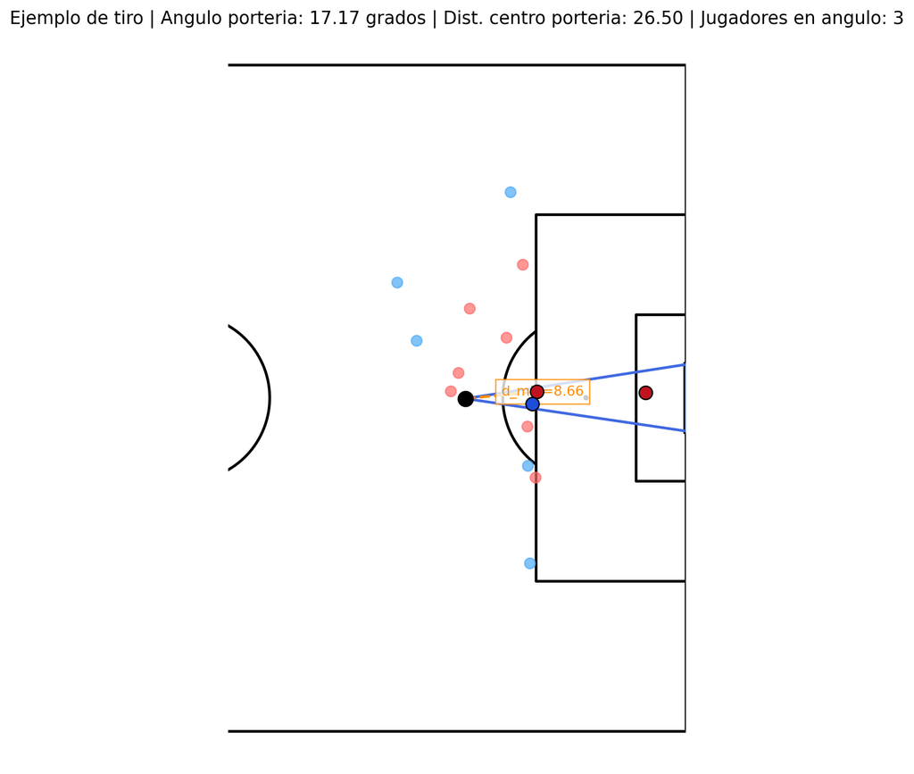

```python
def plot_ejemplo_angulo_rivales(df):
  # Selecciona un tiro con al menos un rival dentro del ángulo; si no hay, usa el primero disponible
  candidatos = df[df['num_rivales_angulo'] > 0]
  if candidatos.empty:
    if df.empty:
      print('No hay tiros disponibles para visualizar.')
      return
    row = df.iloc[0]
  else:
    row = candidatos.iloc[11]

  x_ball, y_ball = row['x'], row['y']
  angulo = row['angulo_porteria']
  distancia_centro = row['distancia_centro_porteria']
  distancia_min = row['distancia_rival_mas_cercano']

  rivales = row['rivales_en_angulo'] if isinstance(row['rivales_en_angulo'], list) else []
  companeros = row['companeros_en_angulo'] if isinstance(row['companeros_en_angulo'], list) else []

  rivales_x = [x for x, y, _ in rivales]
  rivales_y = [y for x, y, _ in rivales]
  companeros_x = [x for x, y, _ in companeros]
  companeros_y = [y for x, y, _ in companeros]

  rivales_block_x = [x for x, y, is_blocking in rivales if is_blocking]
  rivales_block_y = [y for x, y, is_blocking in rivales if is_blocking]
  companeros_block_x = [x for x, y, is_blocking in companeros if is_blocking]
  companeros_block_y = [y for x, y, is_blocking in companeros if is_blocking]

  pitch = Pitch(pitch_type='statsbomb', line_color='black', pitch_color='white')
  fig, ax = pitch.draw(figsize=(12, 8))

  # Mostrar solo la parte derecha del campo para dar efecto de zoom.
  ax.set_xlim(65, 120)

  # Triángulo visual del ángulo balón-portería
  ax.plot([x_ball, POSTE_1[0]], [y_ball, POSTE_1[1]], color='royalblue', linewidth=2, zorder=2)
  ax.plot([x_ball, POSTE_2[0]], [y_ball, POSTE_2[1]], color='royalblue', linewidth=2, zorder=2)
  ax.plot([POSTE_1[0], POSTE_2[0]], [POSTE_1[1], POSTE_2[1]], color='royalblue', linewidth=2, zorder=2)

  # Balón (punto de tiro)
  pitch.scatter([x_ball], [y_ball], ax=ax, color='black', s=120, marker='o', zorder=4)

  # Rivales en rojo (más intenso dentro del ángulo)
  if len(rivales_x) > 0:
    pitch.scatter(rivales_x, rivales_y, ax=ax, color='#ff6b6b', s=60, alpha=0.7, zorder=3)
  if len(rivales_block_x) > 0:
    pitch.scatter(rivales_block_x, rivales_block_y, ax=ax, color='#c1121f', edgecolors='black', s=95, zorder=4)

  # Companeros en azul (más intenso dentro del ángulo)
  if len(companeros_x) > 0:
    pitch.scatter(companeros_x, companeros_y, ax=ax, color='#4dabf7', s=60, alpha=0.7, zorder=3)
  if len(companeros_block_x) > 0:
    pitch.scatter(companeros_block_x, companeros_block_y, ax=ax, color='#1d4ed8', edgecolors='black', s=95, zorder=4)

  # Rival más cercano dentro del ángulo
  if len(rivales_block_x) > 0 and pd.notna(distancia_min):
    distancias = [((x - x_ball)**2 + (y - y_ball)**2)**0.5 for x, y in zip(rivales_block_x, rivales_block_y)]
    idx_min = int(np.argmin(distancias))
    x_near = rivales_block_x[idx_min]
    y_near = rivales_block_y[idx_min]

    ax.plot([x_ball, x_near], [y_ball, y_near], color='darkorange', linestyle='--', linewidth=2, zorder=3)
    ax.text(
      (x_ball + x_near) / 2,
      (y_ball + y_near) / 2,
      f"d_min={distancia_min:.2f}",
      color='darkorange',
      fontsize=10,
      bbox=dict(facecolor='white', edgecolor='darkorange', alpha=0.8),
    )

  titulo = (
    f"Ejemplo de tiro | Angulo porteria: {angulo:.2f} grados | "
    f"Dist. centro porteria: {distancia_centro:.2f} | "
    f"Jugadores en angulo: {int(row['num_jugadores_angulo'])}"
  )
  ax.set_title(titulo, fontsize=13)

  plt.show()


plot_ejemplo_angulo_rivales(shots_360_limpio)
```

# 5 Cálculo de métrica de Probabilidad de Gol

## 5.1 Cálculo de Probabilidad de Gol para el Lanzador

**Mostrar código**

```python
LAMBDA_METRICA = 0.08
ALPHA = 0.6

if shots_360_limpio.empty:
  raise ValueError('No hay tiros disponibles para calcular la probabilidad de gol.')

# Tomamos un solo disparo de ejemplo para toda esta sección.
tiro_ejemplo = shots_360_limpio.iloc[[1]].copy()


def calcular_probabilidad_gol(num_rivales_angulo, distancia_rival_mas_cercano, distancia_porteria):
  if pd.isna(distancia_porteria) or distancia_porteria <= 0:
    return np.nan

  # Si no hay defensor bloqueando, el término inverso se toma como 0.
  if pd.isna(distancia_rival_mas_cercano) or distancia_rival_mas_cercano <= 0:
    termino_defensor_cercano = 0.0
  else:
    termino_defensor_cercano = (1 - ALPHA) / distancia_rival_mas_cercano

  prob = np.exp(
    -LAMBDA_METRICA * distancia_porteria
    -ALPHA * num_rivales_angulo
    -termino_defensor_cercano
  )

  return float(np.clip(prob, 0.0, 1.0))


# Para el lanzador reutilizamos directamente las métricas ya calculadas arriba.
tiro_ejemplo['prob_gol_lanzador'] = tiro_ejemplo.apply(
  lambda row: calcular_probabilidad_gol(
    num_rivales_angulo=row['num_rivales_angulo'],
    distancia_rival_mas_cercano=row['distancia_rival_mas_cercano'],
    distancia_porteria=row['distancia_centro_porteria'],
  ),
  axis=1,
)


tabla_lanzador_prob_gol = tiro_ejemplo[[
  'id',
  'player_name',
  'num_rivales_angulo',
  'distancia_rival_mas_cercano',
  'distancia_centro_porteria',
  'prob_gol_lanzador',
]].rename(columns={
  'id': 'id_evento',
  'player_name': 'jugador',
  'num_rivales_angulo': 'num_rivales_angulo',
  'distancia_rival_mas_cercano': 'distancia_rival_mas_cercano',
  'distancia_centro_porteria': 'distancia_porteria',
  'prob_gol_lanzador': 'probabilidad_gol',
})

tabla_lanzador_prob_gol.style.format({
  'distancia_rival_mas_cercano': '{:.2f}',
  'distancia_porteria': '{:.2f}',
  'probabilidad_gol': '{:.3f}',
}).hide(axis='index')
```

| id_evento | jugador | num_rivales_angulo | distancia_rival_mas_cercano | distancia_porteria | probabilidad_gol |
| --- | --- | --- | --- | --- | --- |
| b2c3d59d-3bef-4f8a-ad86-26b69940c64e | Jonathan Tah | 1 | 6.89 | 9.59 | 0.240 |

## 5.2 Cálculo de Probabilidad de Gol para el resto de compañeros

**Mostrar código**

```python
def calcular_metricas_punto(x_ref, y_ref, lista_rivales):
  distancia_porteria = ((120 - x_ref)**2 + (40 - y_ref)**2)**0.5

  numerador = (120 - x_ref)**2 + (36 - y_ref) * (44 - y_ref)
  denominador = (
    ((120 - x_ref)**2 + (36 - y_ref)**2)**0.5
    *
    ((120 - x_ref)**2 + (44 - y_ref)**2)**0.5
  )
  angulo = np.degrees(np.arccos(np.clip(numerador / denominador, -1.0, 1.0))) if denominador != 0 else np.nan

  rivales_tripleta = []
  for rival in (lista_rivales if isinstance(lista_rivales, list) else []):
    x_rival = rival.get('x', np.nan)
    y_rival = rival.get('y', np.nan)

    if pd.isna(x_rival) or pd.isna(y_rival):
      continue

    is_blocking = punto_en_triangulo(x_rival, y_rival, x_ref, y_ref)
    rivales_tripleta.append((x_rival, y_rival, is_blocking))

  num_rivales = sum(1 for _, _, is_blocking in rivales_tripleta if is_blocking)
  distancias = [
    ((x_rival - x_ref)**2 + (y_rival - y_ref)**2)**0.5
    for x_rival, y_rival, is_blocking in rivales_tripleta
    if is_blocking
  ]
  distancia_rival_min = min(distancias) if distancias else np.nan
  prob = calcular_probabilidad_gol(num_rivales, distancia_rival_min, distancia_porteria)

  return {
    'angulo_porteria_companero': angulo,
    'num_rivales_angulo_companero': num_rivales,
    'distancia_centro_porteria_companero': distancia_porteria,
    'distancia_rival_mas_cercano_companero': distancia_rival_min,
    'prob_gol_companero': prob,
  }


def calcular_metricas_companeros(row):
  lista_companeros = row['posiciones_compañeros'] if isinstance(row['posiciones_compañeros'], list) else []
  lista_rivales = row['posiciones_rivales'] if isinstance(row['posiciones_rivales'], list) else []
  resultados = []

  for idx, comp in enumerate(lista_companeros, start=1):
    x_comp = comp.get('x', np.nan)
    y_comp = comp.get('y', np.nan)

    if pd.isna(x_comp) or pd.isna(y_comp):
      continue

    metricas = calcular_metricas_punto(x_comp, y_comp, lista_rivales)
    metricas['id_companero_frame'] = idx
    metricas['x_companero'] = x_comp
    metricas['y_companero'] = y_comp
    resultados.append(metricas)

  return resultados


tiro_ejemplo['metricas_companeros'] = tiro_ejemplo.apply(calcular_metricas_companeros, axis=1)

tiro_ejemplo[['metricas_companeros']].head()

companeros_detalle = []
for _, row in tiro_ejemplo.iterrows():
  id_evento = row.get('id', np.nan)
  jugador_lanzador = row.get('player_name', '')

  companeros_detalle.append({
    'id_evento': id_evento,
    'jugador': jugador_lanzador,
    'tipo_jugador': 'Lanzador',
    'id_companero': 0,
    'x_companero': row.get('x', np.nan),
    'y_companero': row.get('y', np.nan),
    'angulo_porteria': row.get('angulo_porteria', np.nan),
    'num_rivales_angulo': row.get('num_rivales_angulo', np.nan),
    'distancia_rival_mas_cercano': row.get('distancia_rival_mas_cercano', np.nan),
    'distancia_porteria': row.get('distancia_centro_porteria', np.nan),
    'probabilidad_gol': row.get('prob_gol_lanzador', np.nan),
    'es_lanzador': True,
  })

  for metricas_companero in (row.get('metricas_companeros', []) if isinstance(row.get('metricas_companeros', []), list) else []):
    companeros_detalle.append({
      'id_evento': id_evento,
      'jugador': f"Companero {metricas_companero.get('id_companero_frame', '')}",
      'tipo_jugador': 'Compañero visible',
      'id_companero': metricas_companero.get('id_companero_frame', np.nan),
      'x_companero': metricas_companero.get('x_companero', np.nan),
      'y_companero': metricas_companero.get('y_companero', np.nan),
      'angulo_porteria': metricas_companero.get('angulo_porteria_companero', np.nan),
      'num_rivales_angulo': metricas_companero.get('num_rivales_angulo_companero', np.nan),
      'distancia_rival_mas_cercano': metricas_companero.get('distancia_rival_mas_cercano_companero', np.nan),
      'distancia_porteria': metricas_companero.get('distancia_centro_porteria_companero', np.nan),
      'probabilidad_gol': metricas_companero.get('prob_gol_companero', np.nan),
      'es_lanzador': False,
    })

companeros_tabla = pd.DataFrame(companeros_detalle)


def resaltar_lanzador(row):
  if bool(row.get('es_lanzador', False)):
    return ['background-color: #1f2937; color: white;'] * len(row)
  return [''] * len(row)


companeros_tabla.style.apply(resaltar_lanzador, axis=1).format({
  'x_companero': '{:.2f}',
  'y_companero': '{:.2f}',
  'angulo_porteria': '{:.2f}',
  'num_rivales_angulo': '{:.0f}',
  'distancia_rival_mas_cercano': '{:.2f}',
  'distancia_porteria': '{:.2f}',
  'probabilidad_gol': '{:.3f}',
}).hide(axis='index')
```

| id_evento | jugador | tipo_jugador | id_companero | x_companero | y_companero | angulo_porteria | num_rivales_angulo | distancia_rival_mas_cercano | distancia_porteria | probabilidad_gol | es_lanzador |
| --- | --- | --- | --- | --- | --- | --- | --- | --- | --- | --- | --- |
| b2c3d59d-3bef-4f8a-ad86-26b69940c64e | Jonathan Tah | Lanzador | 0 | 113.90 | 47.40 | 32.72 | 1 | 6.89 | 9.59 | 0.240 | True |
| b2c3d59d-3bef-4f8a-ad86-26b69940c64e | Companero 1 | Compañero visible | 1 | 95.08 | 50.60 | 15.53 | 3 | 19.06 | 27.08 | 0.019 | False |
| b2c3d59d-3bef-4f8a-ad86-26b69940c64e | Companero 2 | Compañero visible | 2 | 110.80 | 39.90 | 46.98 | 3 | 0.58 | 9.20 | 0.040 | False |
| b2c3d59d-3bef-4f8a-ad86-26b69940c64e | Companero 3 | Compañero visible | 3 | 111.26 | 47.76 | 30.10 | 1 | 8.97 | 11.69 | 0.206 | False |
| b2c3d59d-3bef-4f8a-ad86-26b69940c64e | Companero 4 | Compañero visible | 4 | 113.51 | 41.34 | 61.71 | 1 | 4.59 | 6.63 | 0.296 | False |
| b2c3d59d-3bef-4f8a-ad86-26b69940c64e | Companero 5 | Compañero visible | 5 | 113.90 | 47.40 | 32.72 | 1 | 6.89 | 9.59 | 0.240 | False |
| b2c3d59d-3bef-4f8a-ad86-26b69940c64e | Companero 6 | Compañero visible | 6 | 114.60 | 7.93 | 2.38 | 0 | nan | 32.52 | 0.074 | False |
| b2c3d59d-3bef-4f8a-ad86-26b69940c64e | Companero 7 | Compañero visible | 7 | 115.82 | 37.79 | 79.22 | 0 | nan | 4.73 | 0.685 | False |
| b2c3d59d-3bef-4f8a-ad86-26b69940c64e | Companero 8 | Compañero visible | 8 | 115.99 | 35.24 | 54.65 | 1 | 1.46 | 6.23 | 0.253 | False |

## 5.3 Comparación entre la Probabilidad de Gol del Lanzador y la del resto de compañeros para evaluar la decisión de tiro

**Mostrar código**

```python
ranking_registros = []

for _, row in tiro_ejemplo.iterrows():
  id_evento = row.get('id', np.nan)
  jugador_lanzador = row.get('player_name', '')

  ranking_registros.append({
    'id_evento': id_evento,
    'jugador': jugador_lanzador,
    'tipo_jugador': 'Lanzador',
    'id_companero': 0,
    'x': row.get('x', np.nan),
    'y': row.get('y', np.nan),
    'angulo_porteria': row.get('angulo_porteria', np.nan),
    'num_rivales_angulo': row.get('num_rivales_angulo', np.nan),
    'distancia_rival_mas_cercano': row.get('distancia_rival_mas_cercano', np.nan),
    'distancia_porteria': row.get('distancia_centro_porteria', np.nan),
    'probabilidad_gol': row.get('prob_gol_lanzador', np.nan),
    'es_lanzador': True,
  })

  for metricas_companero in (row.get('metricas_companeros', []) if isinstance(row.get('metricas_companeros', []), list) else []):
    ranking_registros.append({
      'id_evento': id_evento,
      'jugador': f"Companero {metricas_companero.get('id_companero_frame', '')}",
      'tipo_jugador': 'Compañero visible',
      'id_companero': metricas_companero.get('id_companero_frame', np.nan),
      'x': metricas_companero.get('x_companero', np.nan),
      'y': metricas_companero.get('y_companero', np.nan),
      'angulo_porteria': metricas_companero.get('angulo_porteria_companero', np.nan),
      'num_rivales_angulo': metricas_companero.get('num_rivales_angulo_companero', np.nan),
      'distancia_rival_mas_cercano': metricas_companero.get('distancia_rival_mas_cercano_companero', np.nan),
      'distancia_porteria': metricas_companero.get('distancia_centro_porteria_companero', np.nan),
      'probabilidad_gol': metricas_companero.get('prob_gol_companero', np.nan),
      'es_lanzador': False,
    })

tabla_ranking = pd.DataFrame(ranking_registros)
tabla_ranking['ranking_probabilidad'] = tabla_ranking.groupby('id_evento')['probabilidad_gol'].rank(ascending=False, method='dense')
tabla_ranking['mejor_prob_evento'] = tabla_ranking.groupby('id_evento')['probabilidad_gol'].transform('max')
prob_lanzador_evento = tabla_ranking.loc[tabla_ranking['es_lanzador'], ['id_evento', 'probabilidad_gol']].set_index('id_evento')['probabilidad_gol']
tabla_ranking['prob_lanzador_evento'] = tabla_ranking['id_evento'].map(prob_lanzador_evento)
tabla_ranking['diferencia_vs_lanzador'] = tabla_ranking['probabilidad_gol'] - tabla_ranking['prob_lanzador_evento']
tabla_ranking['decision_optima_tiro'] = tabla_ranking['probabilidad_gol'] >= tabla_ranking['mejor_prob_evento']

tabla_ranking = tabla_ranking.sort_values(
  ['id_evento', 'ranking_probabilidad', 'probabilidad_gol'],
  ascending=[True, True, False],
)

def resaltar_lanzador_ranking(row):
  if bool(row.get('es_lanzador', False)):
    return ['background-color: #1f2937; color: white;'] * len(row)
  return [''] * len(row)


tabla_ranking.style.apply(resaltar_lanzador_ranking, axis=1).format({
  'angulo_porteria': '{:.2f}',
  'num_rivales_angulo': '{:.0f}',
  'distancia_rival_mas_cercano': '{:.2f}',
  'distancia_porteria': '{:.2f}',
  'probabilidad_gol': '{:.3f}',
  'prob_lanzador_evento': '{:.3f}',
  'ranking_probabilidad': '{:.0f}',
  'mejor_prob_evento': '{:.3f}',
  'diferencia_vs_lanzador': '{:.3f}',
}).hide(axis='index')
```

| id_evento | jugador | tipo_jugador | id_companero | x | y | angulo_porteria | num_rivales_angulo | distancia_rival_mas_cercano | distancia_porteria | probabilidad_gol | es_lanzador | ranking_probabilidad | mejor_prob_evento | prob_lanzador_evento | diferencia_vs_lanzador | decision_optima_tiro |
| --- | --- | --- | --- | --- | --- | --- | --- | --- | --- | --- | --- | --- | --- | --- | --- | --- |
| b2c3d59d-3bef-4f8a-ad86-26b69940c64e | Companero 7 | Compañero visible | 7 | 115.821070 | 37.785688 | 79.22 | 0 | nan | 4.73 | 0.685 | False | 1 | 0.685 | 0.240 | 0.445 | True |
| b2c3d59d-3bef-4f8a-ad86-26b69940c64e | Companero 4 | Compañero visible | 4 | 113.508171 | 41.344732 | 61.71 | 1 | 4.59 | 6.63 | 0.296 | False | 2 | 0.685 | 0.240 | 0.056 | False |
| b2c3d59d-3bef-4f8a-ad86-26b69940c64e | Companero 8 | Compañero visible | 8 | 115.988770 | 35.238077 | 54.65 | 1 | 1.46 | 6.23 | 0.253 | False | 3 | 0.685 | 0.240 | 0.013 | False |
| b2c3d59d-3bef-4f8a-ad86-26b69940c64e | Jonathan Tah | Lanzador | 0 | 113.900000 | 47.400000 | 32.72 | 1 | 6.89 | 9.59 | 0.240 | True | 4 | 0.685 | 0.240 | 0.000 | False |
| b2c3d59d-3bef-4f8a-ad86-26b69940c64e | Companero 5 | Compañero visible | 5 | 113.900002 | 47.400002 | 32.72 | 1 | 6.89 | 9.59 | 0.240 | False | 5 | 0.685 | 0.240 | -0.000 | False |
| b2c3d59d-3bef-4f8a-ad86-26b69940c64e | Companero 3 | Compañero visible | 3 | 111.262763 | 47.761617 | 30.10 | 1 | 8.97 | 11.69 | 0.206 | False | 6 | 0.685 | 0.240 | -0.034 | False |
| b2c3d59d-3bef-4f8a-ad86-26b69940c64e | Companero 6 | Compañero visible | 6 | 114.596476 | 7.932343 | 2.38 | 0 | nan | 32.52 | 0.074 | False | 7 | 0.685 | 0.240 | -0.166 | False |
| b2c3d59d-3bef-4f8a-ad86-26b69940c64e | Companero 2 | Compañero visible | 2 | 110.797947 | 39.895943 | 46.98 | 3 | 0.58 | 9.20 | 0.040 | False | 8 | 0.685 | 0.240 | -0.201 | False |
| b2c3d59d-3bef-4f8a-ad86-26b69940c64e | Companero 1 | Compañero visible | 1 | 95.078992 | 50.597634 | 15.53 | 3 | 19.06 | 27.08 | 0.019 | False | 9 | 0.685 | 0.240 | -0.222 | False |

## 5.4 Paso extra. Probabilidad de Gol solo con compañeros a los que se podía pasar

**Mostrar código**

```python
RADIO_INTERCEPCION_PASE = 2.0


def distancia_punto_a_segmento(px, py, x1, y1, x2, y2):
  dx = x2 - x1
  dy = y2 - y1
  longitud_cuadrado = dx**2 + dy**2

  if longitud_cuadrado == 0:
    return ((px - x1)**2 + (py - y1)**2)**0.5, 0.0

  t = ((px - x1) * dx + (py - y1) * dy) / longitud_cuadrado
  t_clamped = max(0.0, min(1.0, t))
  x_proy = x1 + t_clamped * dx
  y_proy = y1 + t_clamped * dy
  distancia = ((px - x_proy)**2 + (py - y_proy)**2)**0.5

  return distancia, t


def rivales_en_linea_de_pase(x_origen, y_origen, x_destino, y_destino, lista_rivales, radio=RADIO_INTERCEPCION_PASE):
  rivales_cortando = []

  if any(pd.isna(valor) for valor in [x_origen, y_origen, x_destino, y_destino]):
    return rivales_cortando

  for idx, rival in enumerate(lista_rivales if isinstance(lista_rivales, list) else [], start=1):
    x_rival = rival.get('x', np.nan)
    y_rival = rival.get('y', np.nan)

    if pd.isna(x_rival) or pd.isna(y_rival):
      continue

    distancia, t = distancia_punto_a_segmento(
      x_rival, y_rival,
      x_origen, y_origen,
      x_destino, y_destino,
    )

    # Solo cuenta si el rival está entre ambos jugadores, no detrás del origen ni pasado el destino.
    if 0 < t < 1 and distancia <= radio:
      rivales_cortando.append({
        'id_rival_frame': idx,
        'x': x_rival,
        'y': y_rival,
        'distancia_linea_pase': distancia,
      })

  return rivales_cortando


def pase_disponible_sin_rival(x_origen, y_origen, x_destino, y_destino, lista_rivales, radio=RADIO_INTERCEPCION_PASE):
  return len(rivales_en_linea_de_pase(x_origen, y_origen, x_destino, y_destino, lista_rivales, radio)) == 0


ranking_pasable_registros = []

for _, row in tiro_ejemplo.iterrows():
  id_evento = row.get('id', np.nan)
  jugador_lanzador = row.get('player_name', '')
  x_lanzador = row.get('x', np.nan)
  y_lanzador = row.get('y', np.nan)
  rivales_frame = row['posiciones_rivales'] if isinstance(row['posiciones_rivales'], list) else []

  ranking_pasable_registros.append({
    'id_evento': id_evento,
    'jugador': jugador_lanzador,
    'tipo_jugador': 'Lanzador',
    'id_companero': 0,
    'x': x_lanzador,
    'y': y_lanzador,
    'pase_posible_sin_rival': True,
    'rivales_cortando_pase': [],
    'num_rivales_cortando_pase': 0,
    'angulo_porteria': row.get('angulo_porteria', np.nan),
    'num_rivales_angulo': row.get('num_rivales_angulo', np.nan),
    'distancia_rival_mas_cercano': row.get('distancia_rival_mas_cercano', np.nan),
    'distancia_porteria': row.get('distancia_centro_porteria', np.nan),
    'probabilidad_gol': row.get('prob_gol_lanzador', np.nan),
    'es_lanzador': True,
  })

  for metricas_companero in (row.get('metricas_companeros', []) if isinstance(row.get('metricas_companeros', []), list) else []):
    x_comp = metricas_companero.get('x_companero', np.nan)
    y_comp = metricas_companero.get('y_companero', np.nan)
    rivales_cortando = rivales_en_linea_de_pase(x_lanzador, y_lanzador, x_comp, y_comp, rivales_frame)
    pase_posible = len(rivales_cortando) == 0

    if not pase_posible:
      continue

    metricas = calcular_metricas_punto(x_comp, y_comp, rivales_frame)

    ranking_pasable_registros.append({
      'id_evento': id_evento,
      'jugador': f"Companero {metricas_companero.get('id_companero_frame', '')}",
      'tipo_jugador': 'Compañero pasable',
      'id_companero': metricas_companero.get('id_companero_frame', np.nan),
      'x': x_comp,
      'y': y_comp,
      'pase_posible_sin_rival': pase_posible,
      'rivales_cortando_pase': rivales_cortando,
      'num_rivales_cortando_pase': len(rivales_cortando),
      'angulo_porteria': metricas.get('angulo_porteria_companero', np.nan),
      'num_rivales_angulo': metricas.get('num_rivales_angulo_companero', np.nan),
      'distancia_rival_mas_cercano': metricas.get('distancia_rival_mas_cercano_companero', np.nan),
      'distancia_porteria': metricas.get('distancia_centro_porteria_companero', np.nan),
      'probabilidad_gol': metricas.get('prob_gol_companero', np.nan),
      'es_lanzador': False,
    })

tabla_ranking_pasable = pd.DataFrame(ranking_pasable_registros)
tabla_ranking_pasable['ranking_probabilidad_pasable'] = tabla_ranking_pasable.groupby('id_evento')['probabilidad_gol'].rank(
  ascending=False,
  method='dense',
)
tabla_ranking_pasable['mejor_prob_evento_pasable'] = tabla_ranking_pasable.groupby('id_evento')['probabilidad_gol'].transform('max')
prob_lanzador_evento_pasable = tabla_ranking_pasable.loc[
  tabla_ranking_pasable['es_lanzador'],
  ['id_evento', 'probabilidad_gol'],
].set_index('id_evento')['probabilidad_gol']
tabla_ranking_pasable['prob_lanzador_evento'] = tabla_ranking_pasable['id_evento'].map(prob_lanzador_evento_pasable)
tabla_ranking_pasable['diferencia_vs_lanzador'] = tabla_ranking_pasable['probabilidad_gol'] - tabla_ranking_pasable['prob_lanzador_evento']
tabla_ranking_pasable['decision_optima_tiro_pasable'] = (
  tabla_ranking_pasable['probabilidad_gol'] >= tabla_ranking_pasable['mejor_prob_evento_pasable']
)

tabla_ranking_pasable = tabla_ranking_pasable.sort_values(
  ['id_evento', 'ranking_probabilidad_pasable', 'probabilidad_gol'],
  ascending=[True, True, False],
)

tabla_ranking_pasable.drop(columns=['rivales_cortando_pase']).style.apply(resaltar_lanzador_ranking, axis=1).format({
  'x': '{:.2f}',
  'y': '{:.2f}',
  'num_rivales_cortando_pase': '{:.0f}',
  'angulo_porteria': '{:.2f}',
  'num_rivales_angulo': '{:.0f}',
  'distancia_rival_mas_cercano': '{:.2f}',
  'distancia_porteria': '{:.2f}',
  'probabilidad_gol': '{:.3f}',
  'ranking_probabilidad_pasable': '{:.0f}',
  'mejor_prob_evento_pasable': '{:.3f}',
  'prob_lanzador_evento': '{:.3f}',
  'diferencia_vs_lanzador': '{:.3f}',
}).hide(axis='index')
```

| id_evento | jugador | tipo_jugador | id_companero | x | y | pase_posible_sin_rival | num_rivales_cortando_pase | angulo_porteria | num_rivales_angulo | distancia_rival_mas_cercano | distancia_porteria | probabilidad_gol | es_lanzador | ranking_probabilidad_pasable | mejor_prob_evento_pasable | prob_lanzador_evento | diferencia_vs_lanzador | decision_optima_tiro_pasable |
| --- | --- | --- | --- | --- | --- | --- | --- | --- | --- | --- | --- | --- | --- | --- | --- | --- | --- | --- |
| b2c3d59d-3bef-4f8a-ad86-26b69940c64e | Jonathan Tah | Lanzador | 0 | 113.90 | 47.40 | True | 0 | 32.72 | 1 | 6.89 | 9.59 | 0.240 | True | 1 | 0.240 | 0.240 | 0.000 | True |
| b2c3d59d-3bef-4f8a-ad86-26b69940c64e | Companero 5 | Compañero pasable | 5 | 113.90 | 47.40 | True | 0 | 32.72 | 1 | 6.89 | 9.59 | 0.240 | False | 2 | 0.240 | 0.240 | -0.000 | False |

## 5.5 Campograma de pases válidos para el tiro de ejemplo

**Mostrar código**

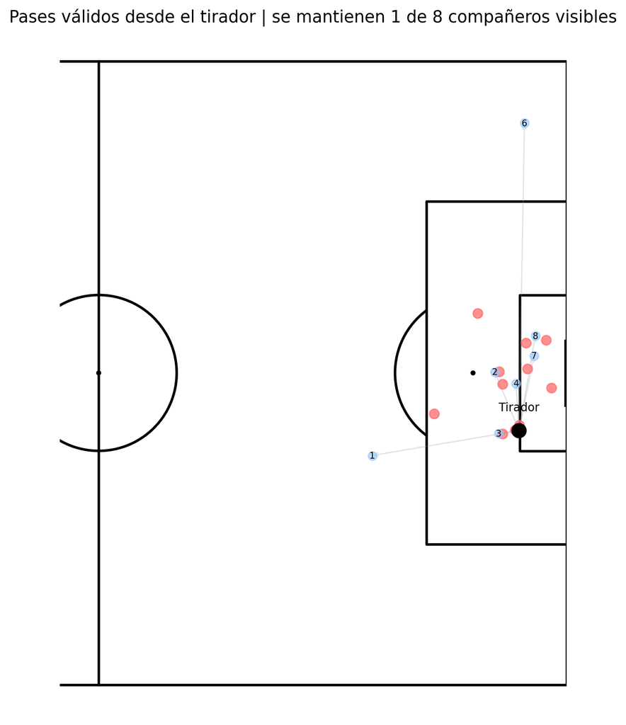

```python
def plot_pases_validos_tiro(row, tabla_pasable):
  companeros_frame = row['posiciones_compañeros'] if isinstance(row['posiciones_compañeros'], list) else []
  rivales_frame = row['posiciones_rivales'] if isinstance(row['posiciones_rivales'], list) else []
  x_origen = row.get('x', np.nan)
  y_origen = row.get('y', np.nan)

  pitch = Pitch(pitch_type='statsbomb', line_color='black', pitch_color='white')
  fig, ax = pitch.draw(figsize=(12, 8))
  ax.set_xlim(55, 120)

  rivales_xy = [
    (r.get('x', np.nan), r.get('y', np.nan))
    for r in rivales_frame
    if not pd.isna(r.get('x', np.nan)) and not pd.isna(r.get('y', np.nan))
  ]
  companeros_xy = [
    (idx, c.get('x', np.nan), c.get('y', np.nan))
    for idx, c in enumerate(companeros_frame, start=1)
    if not pd.isna(c.get('x', np.nan)) and not pd.isna(c.get('y', np.nan))
  ]

  ids_pasables = set(
    tabla_pasable.loc[tabla_pasable['es_lanzador'] == False, 'id_companero']
    .dropna()
    .astype(int)
    .tolist()
  )

  if len(rivales_xy) > 0:
    pitch.scatter([x for x, _ in rivales_xy], [y for _, y in rivales_xy], ax=ax, color='#ff6b6b', s=55, alpha=0.75, zorder=3)

  for idx, x_comp, y_comp in companeros_xy:
    es_pasable = idx in ids_pasables
    color_linea = 'darkgreen' if es_pasable else '#9ca3af'
    alpha_linea = 0.95 if es_pasable else 0.3
    ancho = 2.2 if es_pasable else 1.0
    pitch.arrows(x_origen, y_origen, x_comp, y_comp, ax=ax, color=color_linea, width=ancho, headwidth=4, alpha=alpha_linea, zorder=2)
    pitch.scatter([x_comp], [y_comp], ax=ax, color=('#16a34a' if es_pasable else '#93c5fd'), s=(80 if es_pasable else 45), alpha=(1.0 if es_pasable else 0.6), zorder=4)
    ax.text(x_comp, y_comp, str(idx), color='black', fontsize=7, ha='center', va='center', zorder=5)

  pitch.scatter([x_origen], [y_origen], ax=ax, color='black', s=120, marker='o', zorder=6)
  ax.text(x_origen, y_origen - 2.5, 'Tirador', ha='center', fontsize=9)
  ax.set_title(
    f"Pases válidos desde el tirador | se mantienen {len(ids_pasables)} de {len(companeros_xy)} compañeros visibles",
    fontsize=13,
  )
  plt.show()


plot_pases_validos_tiro(tiro_ejemplo.iloc[0], tabla_ranking_pasable)
```

## 5.6 Grid de campogramas por jugador en el tiro de ejemplo

**Mostrar código**

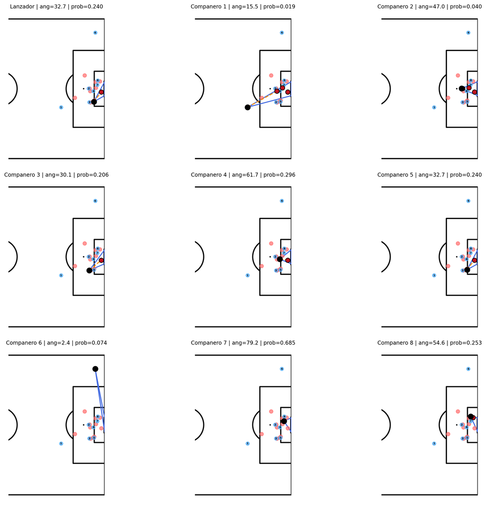

```python
def plot_grid_jugadores_tiro(row, ncols=3):
  companeros_frame = row['posiciones_compañeros'] if isinstance(row['posiciones_compañeros'], list) else []
  rivales_frame = row['posiciones_rivales'] if isinstance(row['posiciones_rivales'], list) else []

  # Candidatos: lanzador real (id frame 0) + cada compañero visible (id frame 1..N)
  candidatos = [{'id_frame': 0, 'x': row['x'], 'y': row['y'], 'es_lanzador': True}]
  for idx, comp in enumerate(companeros_frame, start=1):
    x_comp = comp.get('x', np.nan)
    y_comp = comp.get('y', np.nan)
    if pd.isna(x_comp) or pd.isna(y_comp):
      continue
    candidatos.append({'id_frame': idx, 'x': x_comp, 'y': y_comp, 'es_lanzador': False})

  n = len(candidatos)
  nrows = int(np.ceil(n / ncols))
  fig, axes = plt.subplots(nrows=nrows, ncols=ncols, figsize=(ncols * 5.0, nrows * 4.0))
  axes = np.array(axes).reshape(-1)
  pitch = Pitch(pitch_type='statsbomb', line_color='black', pitch_color='white')

  # Posiciones válidas para dibujar jugadores del frame en todos los subplots
  rivales_xy = [
    (r.get('x', np.nan), r.get('y', np.nan))
    for r in rivales_frame
    if not pd.isna(r.get('x', np.nan)) and not pd.isna(r.get('y', np.nan))
  ]
  companeros_xy = [
    (c.get('x', np.nan), c.get('y', np.nan))
    for c in companeros_frame
    if not pd.isna(c.get('x', np.nan)) and not pd.isna(c.get('y', np.nan))
  ]

  for ax_idx, ax in enumerate(axes):
    if ax_idx >= n:
      ax.axis('off')
      continue

    cand = candidatos[ax_idx]
    x_ref, y_ref = cand['x'], cand['y']

    metricas = calcular_metricas_punto(x_ref, y_ref, rivales_frame)
    angulo = metricas['angulo_porteria_companero']
    prob = metricas['prob_gol_companero']
    d_min = metricas['distancia_rival_mas_cercano_companero']

    # Rivales bloqueando desde la perspectiva del candidato actual
    rivales_tripleta = []
    for rival in rivales_frame:
      x_rival = rival.get('x', np.nan)
      y_rival = rival.get('y', np.nan)
      if pd.isna(x_rival) or pd.isna(y_rival):
        continue
      is_blocking = punto_en_triangulo(x_rival, y_rival, x_ref, y_ref)
      rivales_tripleta.append((x_rival, y_rival, is_blocking))

    rivales_block_x = [x for x, y, b in rivales_tripleta if b]
    rivales_block_y = [y for x, y, b in rivales_tripleta if b]

    pitch.draw(ax=ax)
    ax.set_xlim(65, 120)

    # Misma representación geométrica que la gráfica del lanzador
    ax.plot([x_ref, POSTE_1[0]], [y_ref, POSTE_1[1]], color='royalblue', linewidth=1.6, zorder=2)
    ax.plot([x_ref, POSTE_2[0]], [y_ref, POSTE_2[1]], color='royalblue', linewidth=1.6, zorder=2)
    ax.plot([POSTE_1[0], POSTE_2[0]], [POSTE_1[1], POSTE_2[1]], color='royalblue', linewidth=1.6, zorder=2)

    if len(rivales_xy) > 0:
      pitch.scatter([x for x, _ in rivales_xy], [y for _, y in rivales_xy], ax=ax, color='#ff6b6b', s=38, alpha=0.7, zorder=3)
    if len(rivales_block_x) > 0:
      pitch.scatter(rivales_block_x, rivales_block_y, ax=ax, color='#c1121f', edgecolors='black', s=58, zorder=4)

    if len(companeros_xy) > 0:
      pitch.scatter([x for x, _ in companeros_xy], [y for _, y in companeros_xy], ax=ax, color='#4dabf7', s=34, alpha=0.75, zorder=3)

    # Candidato actual en negro
    pitch.scatter([x_ref], [y_ref], ax=ax, color='black', s=78, marker='o', zorder=5)
    ax.text(x_ref, y_ref, str(cand['id_frame']), color='black', fontsize=5, ha='center', va='center', zorder=6, fontweight='bold')

    # IDs de compañeros del frame
    for idx_comp, (x_comp, y_comp) in enumerate(companeros_xy, start=1):
      ax.text(x_comp, y_comp, str(idx_comp), color='black', fontsize=4.3, ha='center', va='center', zorder=6, fontweight='bold')

    # Distancia al rival más cercano bloqueando
    if len(rivales_block_x) > 0 and pd.notna(d_min):
      distancias = [((x - x_ref)**2 + (y - y_ref)**2)**0.5 for x, y in zip(rivales_block_x, rivales_block_y)]
      idx_min = int(np.argmin(distancias))
      x_near = rivales_block_x[idx_min]
      y_near = rivales_block_y[idx_min]
      ax.plot([x_ref, x_near], [y_ref, y_near], color='darkorange', linestyle='--', linewidth=1.6, zorder=3)

    tipo = 'Lanzador' if cand['es_lanzador'] else f"Companero {cand['id_frame']}"
    ax.set_title(f"{tipo} | ang={angulo:.1f} | prob={prob:.3f}", fontsize=9)

  plt.tight_layout()
  plt.show()


plot_grid_jugadores_tiro(tiro_ejemplo.iloc[0], ncols=3)
```

# 6 Análisis de probabilidad de asistencia con el pase previo al tiro

En esta sección repetimos la lógica anterior, pero cambiando la pregunta: en lugar de evaluar si el jugador que tira tenía la mejor probabilidad de gol, evaluamos si el pase previo encontró a un receptor con alta probabilidad de marcar. Para ello usamos el evento de pase inmediatamente anterior al tiro y su propio frame 360.

## 6.1 Paso 1. Unir cada tiro con su pase previo y el 360 del pase

**Mostrar código**

```python
all_pre_shot_passes_360 = pd.read_parquet('data_processed/all_pre_shot_passes_360_processed.parquet')
all_shots_para_pases = pd.read_parquet('data_processed/all_shots_360_processed.parquet')


def parsear_columna_json_360(df, columnas):
  df = df.copy()
  for col in columnas:
    if col in df.columns:
      df[col] = df[col].apply(
        lambda x: json.loads(x) if isinstance(x, str) and x else (x if isinstance(x, list) else [])
      )
  return df


cols_json_360 = [
  'posiciones_compañeros',
  'posiciones_rivales',
  'posiciones_porteros',
  'visible_area_360',
  'freeze_frame_360',
]

all_pre_shot_passes_360 = parsear_columna_json_360(all_pre_shot_passes_360, cols_json_360)
all_shots_para_pases = parsear_columna_json_360(all_shots_para_pases, cols_json_360)

col_possesion_pase = 'possession_team_name'
if col_possesion_pase not in all_pre_shot_passes_360.columns:
  col_possesion_pase = 'possesion_team_name'

if col_possesion_pase in all_pre_shot_passes_360.columns:
  all_pre_shot_passes_360 = all_pre_shot_passes_360[
    all_pre_shot_passes_360[col_possesion_pase] == 'Bayer Leverkusen'
  ].copy()

cols_shot_merge = [
  'match_id', 'id', 'player_name', 'team_name', 'x', 'y', 'outcome_name',
  'shot_statsbomb_xg', 'is_goal',
]
cols_shot_merge = [col for col in cols_shot_merge if col in all_shots_para_pases.columns]

pases_tiro_360 = all_pre_shot_passes_360.merge(
  all_shots_para_pases[cols_shot_merge],
  left_on=['match_id', 'shot_id'],
  right_on=['match_id', 'id'],
  how='left',
  suffixes=('_pase', '_tiro'),
)

pases_tiro_360 = pases_tiro_360.rename(columns={
  'id': 'id_tiro_merge',
  'player_name_pase': 'pasador',
  'player_name_tiro': 'tirador',
  'x_pase': 'x_pase',
  'y_pase': 'y_pase',
  'end_x': 'x_fin_pase',
  'end_y': 'y_fin_pase',
  'x_tiro': 'x_tiro',
  'y_tiro': 'y_tiro',
})

pases_tiro_360 = pases_tiro_360[pases_tiro_360['pass_has_360'] == True].copy()

pases_tiro_360[[
  'match_id', 'shot_id', 'pass_id', 'pasador', 'tirador',
  'x_pase', 'y_pase', 'x_fin_pase', 'y_fin_pase', 'x_tiro', 'y_tiro',
  'pass_has_360',
]].head()
```

|  | match_id | shot_id | pass_id | pasador | tirador | x_pase | y_pase | x_fin_pase | y_fin_pase | x_tiro | y_tiro | pass_has_360 |
| --- | --- | --- | --- | --- | --- | --- | --- | --- | --- | --- | --- | --- |
| 0 | 3895302 | bbc2c68d-c096-483d-abf4-32c0175a0f55 | 95ee2820-c4dc-44f2-9fe7-d24cb6edd881 | Nathan Tella | Piero Martín Hincapié Reyna | 111.0 | 69.2 | 114.6 | 33.5 | 114.6 | 33.5 | True |
| 1 | 3895302 | b2c3d59d-3bef-4f8a-ad86-26b69940c64e | f11e6dbe-665c-4c05-a7cb-aa361d8a0bf2 | Jonas Hofmann | Jonathan Tah | 120.0 | 0.1 | 113.9 | 47.6 | 113.9 | 47.4 | True |
| 2 | 3895302 | bb53b537-1685-4019-9e8f-98f3805828eb | 576aece9-65d9-43bb-bb33-48c2943ef53f | Robert Andrich | Granit Xhaka | 87.9 | 37.1 | 87.6 | 46.0 | 89.2 | 42.5 | True |
| 3 | 3895302 | 0247fb51-7bf7-4be6-82d7-bf63892bdd53 | d2891ba9-b139-4666-9791-c0b6a923ecea | Jonas Hofmann | Jonathan Tah | 120.0 | 80.0 | 110.2 | 32.6 | 110.2 | 32.6 | True |
| 4 | 3895302 | cf7357c9-3bd6-425f-ac34-ef7f11897394 | 25a92cea-33f0-431b-8466-614b826f8918 | Nathan Tella | Victor Okoh Boniface | 107.2 | 65.8 | 110.2 | 39.0 | 108.0 | 40.0 | True |

## 6.2 Paso 2. Seleccionar un pase de ejemplo asociado a un tiro

**Mostrar código**

```python
candidatos_pase = pases_tiro_360[
  (pases_tiro_360['posiciones_compañeros'].apply(lambda x: isinstance(x, list) and len(x) > 1))
  &
  (pases_tiro_360['posiciones_rivales'].apply(lambda x: isinstance(x, list) and len(x) > 0))
].copy()

if candidatos_pase.empty:
  if pases_tiro_360.empty:
    raise ValueError('No hay pases previos a tiro con 360 para analizar.')
  pase_ejemplo = pases_tiro_360.iloc[[0]].copy()
else:
  pase_ejemplo = candidatos_pase.iloc[[0]].copy()

pase_ejemplo[[
  'match_id', 'shot_id', 'pass_id', 'pasador', 'tirador',
  'x_pase', 'y_pase', 'x_fin_pase', 'y_fin_pase', 'x_tiro', 'y_tiro',
]]
```

|  | match_id | shot_id | pass_id | pasador | tirador | x_pase | y_pase | x_fin_pase | y_fin_pase | x_tiro | y_tiro |
| --- | --- | --- | --- | --- | --- | --- | --- | --- | --- | --- | --- |
| 0 | 3895302 | bbc2c68d-c096-483d-abf4-32c0175a0f55 | 95ee2820-c4dc-44f2-9fe7-d24cb6edd881 | Nathan Tella | Piero Martín Hincapié Reyna | 111.0 | 69.2 | 114.6 | 33.5 | 114.6 | 33.5 |

## 6.3 Paso 3. Calcular la probabilidad de gol de cada posible receptor

**Mostrar código**

```python
def es_actor_pase(jugador, x_pase, y_pase, tolerancia=1.5):
  if bool(jugador.get('actor', False)):
    return True

  x_jugador = jugador.get('x', np.nan)
  y_jugador = jugador.get('y', np.nan)
  if pd.isna(x_jugador) or pd.isna(y_jugador) or pd.isna(x_pase) or pd.isna(y_pase):
    return False

  return ((x_jugador - x_pase)**2 + (y_jugador - y_pase)**2)**0.5 <= tolerancia


def calcular_probabilidad_asistencia_pase(row):
  lista_companeros = row['posiciones_compañeros'] if isinstance(row['posiciones_compañeros'], list) else []
  lista_rivales = row['posiciones_rivales'] if isinstance(row['posiciones_rivales'], list) else []
  x_pase = row.get('x_pase', np.nan)
  y_pase = row.get('y_pase', np.nan)
  x_fin_pase = row.get('x_fin_pase', np.nan)
  y_fin_pase = row.get('y_fin_pase', np.nan)

  resultados = []
  for idx, comp in enumerate(lista_companeros, start=1):
    x_comp = comp.get('x', np.nan)
    y_comp = comp.get('y', np.nan)

    if pd.isna(x_comp) or pd.isna(y_comp):
      continue

    if es_actor_pase(comp, x_pase, y_pase):
      continue

    metricas = calcular_metricas_punto(x_comp, y_comp, lista_rivales)
    distancia_al_destino_real = (
      ((x_comp - x_fin_pase)**2 + (y_comp - y_fin_pase)**2)**0.5
      if pd.notna(x_fin_pase) and pd.notna(y_fin_pase)
      else np.nan
    )

    resultados.append({
      'id_receptor_frame': idx,
      'x_receptor': x_comp,
      'y_receptor': y_comp,
      'distancia_al_destino_real': distancia_al_destino_real,
      'angulo_porteria': metricas['angulo_porteria_companero'],
      'num_rivales_angulo': metricas['num_rivales_angulo_companero'],
      'distancia_rival_mas_cercano': metricas['distancia_rival_mas_cercano_companero'],
      'distancia_porteria': metricas['distancia_centro_porteria_companero'],
      'probabilidad_asistencia': metricas['prob_gol_companero'],
    })

  if len(resultados) > 0 and any(pd.notna(r['distancia_al_destino_real']) for r in resultados):
    idx_receptor_real = int(np.nanargmin([r['distancia_al_destino_real'] for r in resultados]))
    for idx, receptor in enumerate(resultados):
      receptor['receptor_real_aproximado'] = idx == idx_receptor_real
  else:
    for receptor in resultados:
      receptor['receptor_real_aproximado'] = False

  return resultados


pase_ejemplo['metricas_receptores'] = pase_ejemplo.apply(calcular_probabilidad_asistencia_pase, axis=1)

receptores_detalle = []
for _, row in pase_ejemplo.iterrows():
  for receptor in row.get('metricas_receptores', []):
    receptores_detalle.append({
      'id_pase': row.get('pass_id', np.nan),
      'id_tiro': row.get('shot_id', np.nan),
      'pasador': row.get('pasador', ''),
      'tirador': row.get('tirador', ''),
      **receptor,
    })

tabla_receptores_pase = pd.DataFrame(receptores_detalle)

if tabla_receptores_pase.empty:
  raise ValueError('El pase de ejemplo no tiene receptores visibles en el frame 360.')

tabla_receptores_pase['ranking_probabilidad'] = tabla_receptores_pase['probabilidad_asistencia'].rank(
  ascending=False,
  method='dense',
)
tabla_receptores_pase['mejor_probabilidad_pase'] = tabla_receptores_pase['probabilidad_asistencia'].max()
prob_receptor_real = tabla_receptores_pase.loc[
  tabla_receptores_pase['receptor_real_aproximado'],
  'probabilidad_asistencia',
]
tabla_receptores_pase['prob_receptor_real'] = prob_receptor_real.iloc[0] if len(prob_receptor_real) > 0 else np.nan
tabla_receptores_pase['diferencia_vs_receptor_real'] = (
  tabla_receptores_pase['probabilidad_asistencia'] - tabla_receptores_pase['prob_receptor_real']
)
tabla_receptores_pase['mejor_opcion_de_pase'] = (
  tabla_receptores_pase['probabilidad_asistencia'] >= tabla_receptores_pase['mejor_probabilidad_pase']
)

tabla_receptores_pase = tabla_receptores_pase.sort_values(
  ['ranking_probabilidad', 'probabilidad_asistencia'],
  ascending=[True, False],
)


def resaltar_receptor_real(row):
  if bool(row.get('receptor_real_aproximado', False)):
    return ['background-color: #1f2937; color: white;'] * len(row)
  if bool(row.get('mejor_opcion_de_pase', False)):
    return ['background-color: #dbeafe;'] * len(row)
  return [''] * len(row)


tabla_receptores_pase.style.apply(resaltar_receptor_real, axis=1).format({
  'x_receptor': '{:.2f}',
  'y_receptor': '{:.2f}',
  'distancia_al_destino_real': '{:.2f}',
  'angulo_porteria': '{:.2f}',
  'num_rivales_angulo': '{:.0f}',
  'distancia_rival_mas_cercano': '{:.2f}',
  'distancia_porteria': '{:.2f}',
  'probabilidad_asistencia': '{:.3f}',
  'ranking_probabilidad': '{:.0f}',
  'mejor_probabilidad_pase': '{:.3f}',
  'prob_receptor_real': '{:.3f}',
  'diferencia_vs_receptor_real': '{:.3f}',
}).hide(axis='index')
```

| id_pase | id_tiro | pasador | tirador | id_receptor_frame | x_receptor | y_receptor | distancia_al_destino_real | angulo_porteria | num_rivales_angulo | distancia_rival_mas_cercano | distancia_porteria | probabilidad_asistencia | receptor_real_aproximado | ranking_probabilidad | mejor_probabilidad_pase | prob_receptor_real | diferencia_vs_receptor_real | mejor_opcion_de_pase |
| --- | --- | --- | --- | --- | --- | --- | --- | --- | --- | --- | --- | --- | --- | --- | --- | --- | --- | --- |
| 95ee2820-c4dc-44f2-9fe7-d24cb6edd881 | bbc2c68d-c096-483d-abf4-32c0175a0f55 | Nathan Tella | Piero Martín Hincapié Reyna | 5 | 107.36 | 48.61 | 16.75 | 24.90 | 0 | nan | 15.30 | 0.294 | False | 1 | 0.294 | 0.186 | 0.108 | True |
| 95ee2820-c4dc-44f2-9fe7-d24cb6edd881 | bbc2c68d-c096-483d-abf4-32c0175a0f55 | Nathan Tella | Piero Martín Hincapié Reyna | 4 | 102.92 | 27.78 | 13.01 | 17.82 | 0 | nan | 21.00 | 0.186 | True | 2 | 0.294 | 0.186 | 0.000 | False |
| 95ee2820-c4dc-44f2-9fe7-d24cb6edd881 | bbc2c68d-c096-483d-abf4-32c0175a0f55 | Nathan Tella | Piero Martín Hincapié Reyna | 3 | 102.59 | 46.41 | 17.63 | 23.00 | 1 | 5.44 | 18.55 | 0.116 | False | 3 | 0.294 | 0.186 | -0.071 | False |
| 95ee2820-c4dc-44f2-9fe7-d24cb6edd881 | bbc2c68d-c096-483d-abf4-32c0175a0f55 | Nathan Tella | Piero Martín Hincapié Reyna | 1 | 94.82 | 57.34 | 30.98 | 12.37 | 1 | 17.47 | 30.58 | 0.046 | False | 4 | 0.294 | 0.186 | -0.140 | False |
| 95ee2820-c4dc-44f2-9fe7-d24cb6edd881 | bbc2c68d-c096-483d-abf4-32c0175a0f55 | Nathan Tella | Piero Martín Hincapié Reyna | 2 | 96.16 | 71.30 | 42.05 | 7.10 | 1 | 17.26 | 39.34 | 0.023 | False | 5 | 0.294 | 0.186 | -0.163 | False |

## 6.4 Paso extra. Probabilidad de asistencia solo con receptores a los que se podía pasar

**Mostrar código**

```python
tabla_receptores_pasables = tabla_receptores_pase.copy()
row_pase = pase_ejemplo.iloc[0]
rivales_frame_pase = row_pase['posiciones_rivales'] if isinstance(row_pase['posiciones_rivales'], list) else []
x_origen_pase = row_pase.get('x_pase', np.nan)
y_origen_pase = row_pase.get('y_pase', np.nan)

tabla_receptores_pasables['rivales_cortando_pase'] = tabla_receptores_pasables.apply(
  lambda row: rivales_en_linea_de_pase(
    x_origen_pase,
    y_origen_pase,
    row['x_receptor'],
    row['y_receptor'],
    rivales_frame_pase,
  ),
  axis=1,
)
tabla_receptores_pasables['num_rivales_cortando_pase'] = tabla_receptores_pasables['rivales_cortando_pase'].apply(len)
tabla_receptores_pasables['pase_posible_sin_rival'] = tabla_receptores_pasables['num_rivales_cortando_pase'] == 0

tabla_receptores_pasables = tabla_receptores_pasables[
  tabla_receptores_pasables['pase_posible_sin_rival']
].copy()

if tabla_receptores_pasables.empty:
  raise ValueError('No hay receptores pasables sin rival en la trayectoria para el pase de ejemplo.')

tabla_receptores_pasables['ranking_probabilidad_pasable'] = tabla_receptores_pasables['probabilidad_asistencia'].rank(
  ascending=False,
  method='dense',
)
tabla_receptores_pasables['mejor_probabilidad_pase_pasable'] = tabla_receptores_pasables['probabilidad_asistencia'].max()
prob_receptor_real_pasable = tabla_receptores_pasables.loc[
  tabla_receptores_pasables['receptor_real_aproximado'],
  'probabilidad_asistencia',
]
tabla_receptores_pasables['prob_receptor_real_pasable'] = (
  prob_receptor_real_pasable.iloc[0] if len(prob_receptor_real_pasable) > 0 else np.nan
)
tabla_receptores_pasables['diferencia_vs_receptor_real_pasable'] = (
  tabla_receptores_pasables['probabilidad_asistencia'] - tabla_receptores_pasables['prob_receptor_real_pasable']
)
tabla_receptores_pasables['mejor_opcion_de_pase_pasable'] = (
  tabla_receptores_pasables['probabilidad_asistencia'] >= tabla_receptores_pasables['mejor_probabilidad_pase_pasable']
)

tabla_receptores_pasables = tabla_receptores_pasables.sort_values(
  ['ranking_probabilidad_pasable', 'probabilidad_asistencia'],
  ascending=[True, False],
)


def resaltar_receptor_pasable(row):
  if bool(row.get('receptor_real_aproximado', False)):
    return ['background-color: #1f2937; color: white;'] * len(row)
  if bool(row.get('mejor_opcion_de_pase_pasable', False)):
    return ['background-color: #dbeafe;'] * len(row)
  return [''] * len(row)


tabla_receptores_pasables.drop(columns=['rivales_cortando_pase']).style.apply(resaltar_receptor_pasable, axis=1).format({
  'x_receptor': '{:.2f}',
  'y_receptor': '{:.2f}',
  'distancia_al_destino_real': '{:.2f}',
  'num_rivales_cortando_pase': '{:.0f}',
  'angulo_porteria': '{:.2f}',
  'num_rivales_angulo': '{:.0f}',
  'distancia_rival_mas_cercano': '{:.2f}',
  'distancia_porteria': '{:.2f}',
  'probabilidad_asistencia': '{:.3f}',
  'ranking_probabilidad_pasable': '{:.0f}',
  'mejor_probabilidad_pase_pasable': '{:.3f}',
  'prob_receptor_real_pasable': '{:.3f}',
  'diferencia_vs_receptor_real_pasable': '{:.3f}',
}).hide(axis='index')
```

| id_pase | id_tiro | pasador | tirador | id_receptor_frame | x_receptor | y_receptor | distancia_al_destino_real | angulo_porteria | num_rivales_angulo | distancia_rival_mas_cercano | distancia_porteria | probabilidad_asistencia | receptor_real_aproximado | ranking_probabilidad | mejor_probabilidad_pase | prob_receptor_real | diferencia_vs_receptor_real | mejor_opcion_de_pase | num_rivales_cortando_pase | pase_posible_sin_rival | ranking_probabilidad_pasable | mejor_probabilidad_pase_pasable | prob_receptor_real_pasable | diferencia_vs_receptor_real_pasable | mejor_opcion_de_pase_pasable |
| --- | --- | --- | --- | --- | --- | --- | --- | --- | --- | --- | --- | --- | --- | --- | --- | --- | --- | --- | --- | --- | --- | --- | --- | --- | --- |
| 95ee2820-c4dc-44f2-9fe7-d24cb6edd881 | bbc2c68d-c096-483d-abf4-32c0175a0f55 | Nathan Tella | Piero Martín Hincapié Reyna | 2 | 96.16 | 71.30 | 42.05 | 7.10 | 1 | 17.26 | 39.34 | 0.023 | False | 5.000000 | 0.294169 | 0.186359 | -0.163318 | False | 0 | True | 1 | 0.023 | nan | nan | True |

## 6.5 Campograma de receptores válidos para el pase de ejemplo

**Mostrar código**

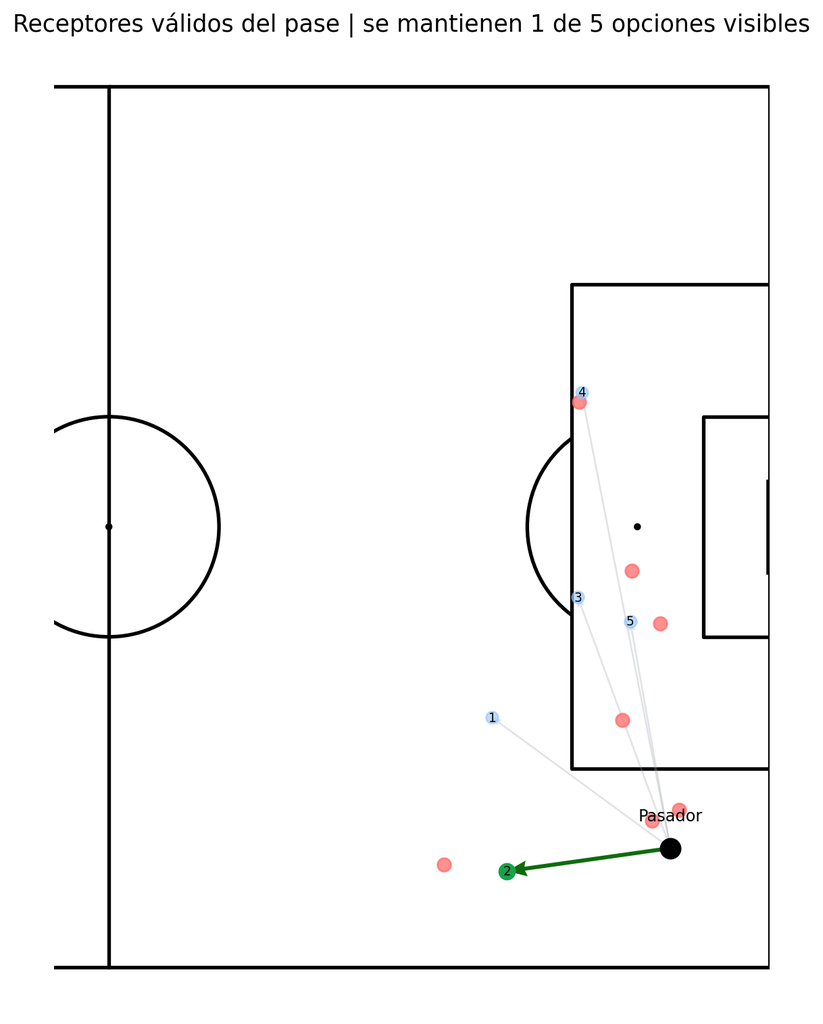

```python
def plot_receptores_validos_pase(row, tabla_pasable):
  companeros_frame = row['posiciones_compañeros'] if isinstance(row['posiciones_compañeros'], list) else []
  rivales_frame = row['posiciones_rivales'] if isinstance(row['posiciones_rivales'], list) else []
  x_origen = row.get('x_pase', np.nan)
  y_origen = row.get('y_pase', np.nan)

  ids_pasables = set(
    tabla_pasable['id_receptor_frame']
    .dropna()
    .astype(int)
    .tolist()
  )
  id_receptor_real = tabla_pasable.loc[
    tabla_pasable['receptor_real_aproximado'],
    'id_receptor_frame',
  ]
  id_receptor_real = int(id_receptor_real.iloc[0]) if len(id_receptor_real) > 0 else None

  pitch = Pitch(pitch_type='statsbomb', line_color='black', pitch_color='white')
  fig, ax = pitch.draw(figsize=(12, 8))
  ax.set_xlim(55, 120)

  rivales_xy = [
    (r.get('x', np.nan), r.get('y', np.nan))
    for r in rivales_frame
    if not pd.isna(r.get('x', np.nan)) and not pd.isna(r.get('y', np.nan))
  ]
  if len(rivales_xy) > 0:
    pitch.scatter([x for x, _ in rivales_xy], [y for _, y in rivales_xy], ax=ax, color='#ff6b6b', s=55, alpha=0.75, zorder=3)

  total_receptores = 0
  for idx, comp in enumerate(companeros_frame, start=1):
    x_comp = comp.get('x', np.nan)
    y_comp = comp.get('y', np.nan)
    if pd.isna(x_comp) or pd.isna(y_comp) or es_actor_pase(comp, x_origen, y_origen):
      continue

    total_receptores += 1
    es_pasable = idx in ids_pasables
    es_real = idx == id_receptor_real
    color_linea = 'darkgreen' if es_pasable else '#9ca3af'
    color_punto = '#16a34a' if es_pasable else '#93c5fd'
    marcador = '*' if es_real else 'o'

    pitch.arrows(x_origen, y_origen, x_comp, y_comp, ax=ax, color=color_linea, width=(2.2 if es_pasable else 1.0), headwidth=4, alpha=(0.95 if es_pasable else 0.3), zorder=2)
    pitch.scatter([x_comp], [y_comp], ax=ax, color=color_punto, edgecolors=('black' if es_real else None), s=(120 if es_real else 75 if es_pasable else 45), marker=marcador, alpha=(1.0 if es_pasable else 0.6), zorder=4)
    ax.text(x_comp, y_comp, str(idx), color='black', fontsize=7, ha='center', va='center', zorder=5)

  pitch.scatter([x_origen], [y_origen], ax=ax, color='black', s=120, marker='o', zorder=6)
  ax.text(x_origen, y_origen - 2.5, 'Pasador', ha='center', fontsize=9)
  ax.set_title(
    f"Receptores válidos del pase | se mantienen {len(ids_pasables)} de {total_receptores} opciones visibles",
    fontsize=13,
  )
  plt.show()


plot_receptores_validos_pase(pase_ejemplo.iloc[0], tabla_receptores_pasables)
```

## 6.6 Paso 4. Campograma del pase real y del tiro asociado

**Mostrar código**

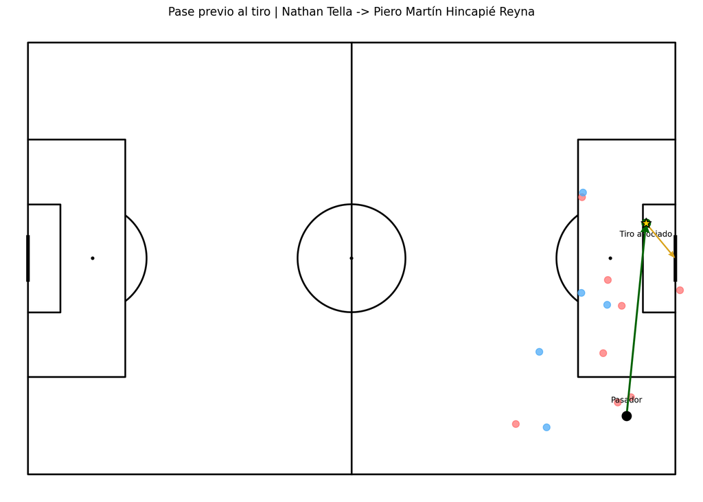

```python
def extraer_xy_frame(lista_jugadores):
  return [
    (jugador.get('x', np.nan), jugador.get('y', np.nan), bool(jugador.get('actor', False)))
    for jugador in (lista_jugadores if isinstance(lista_jugadores, list) else [])
    if not pd.isna(jugador.get('x', np.nan)) and not pd.isna(jugador.get('y', np.nan))
  ]


def plot_pase_y_tiro_asociado(row):
  companeros_frame = row['posiciones_compañeros'] if isinstance(row['posiciones_compañeros'], list) else []
  rivales_frame = row['posiciones_rivales'] if isinstance(row['posiciones_rivales'], list) else []

  companeros_xy = extraer_xy_frame(companeros_frame)
  rivales_xy = extraer_xy_frame(rivales_frame)

  pitch = Pitch(pitch_type='statsbomb', line_color='black', pitch_color='white')
  fig, ax = pitch.draw(figsize=(12, 8))

  if len(rivales_xy) > 0:
    pitch.scatter([x for x, _, _ in rivales_xy], [y for _, y, _ in rivales_xy], ax=ax, color='#ff6b6b', s=60, alpha=0.7, zorder=3)
  if len(companeros_xy) > 0:
    pitch.scatter([x for x, _, _ in companeros_xy], [y for _, y, _ in companeros_xy], ax=ax, color='#4dabf7', s=60, alpha=0.75, zorder=3)

  x_pase, y_pase = row.get('x_pase', np.nan), row.get('y_pase', np.nan)
  x_fin, y_fin = row.get('x_fin_pase', np.nan), row.get('y_fin_pase', np.nan)
  x_tiro, y_tiro = row.get('x_tiro', np.nan), row.get('y_tiro', np.nan)

  if pd.notna(x_pase) and pd.notna(y_pase):
    pitch.scatter([x_pase], [y_pase], ax=ax, color='black', s=110, marker='o', zorder=5)
    ax.text(x_pase, y_pase - 2.5, 'Pasador', ha='center', fontsize=9)

  if pd.notna(x_pase) and pd.notna(y_pase) and pd.notna(x_fin) and pd.notna(y_fin):
    pitch.arrows(x_pase, y_pase, x_fin, y_fin, ax=ax, color='darkgreen', width=2.2, headwidth=5, zorder=4)
    pitch.scatter([x_fin], [y_fin], ax=ax, color='darkgreen', s=95, marker='o', zorder=5)

  if pd.notna(x_tiro) and pd.notna(y_tiro):
    pitch.scatter([x_tiro], [y_tiro], ax=ax, color='gold', edgecolors='black', s=140, marker='*', zorder=6)
    pitch.arrows(x_tiro, y_tiro, 120, 40, ax=ax, color='goldenrod', width=1.7, headwidth=4, zorder=4)
    ax.text(x_tiro, y_tiro + 2.5, 'Tiro asociado', ha='center', fontsize=9)

  ax.set_title(
    f"Pase previo al tiro | {row.get('pasador', '')} -> {row.get('tirador', '')}",
    fontsize=13,
  )
  plt.show()


plot_pase_y_tiro_asociado(pase_ejemplo.iloc[0])
```

## 6.7 Paso 5. Campograma de la mejor opción de asistencia

**Mostrar código**

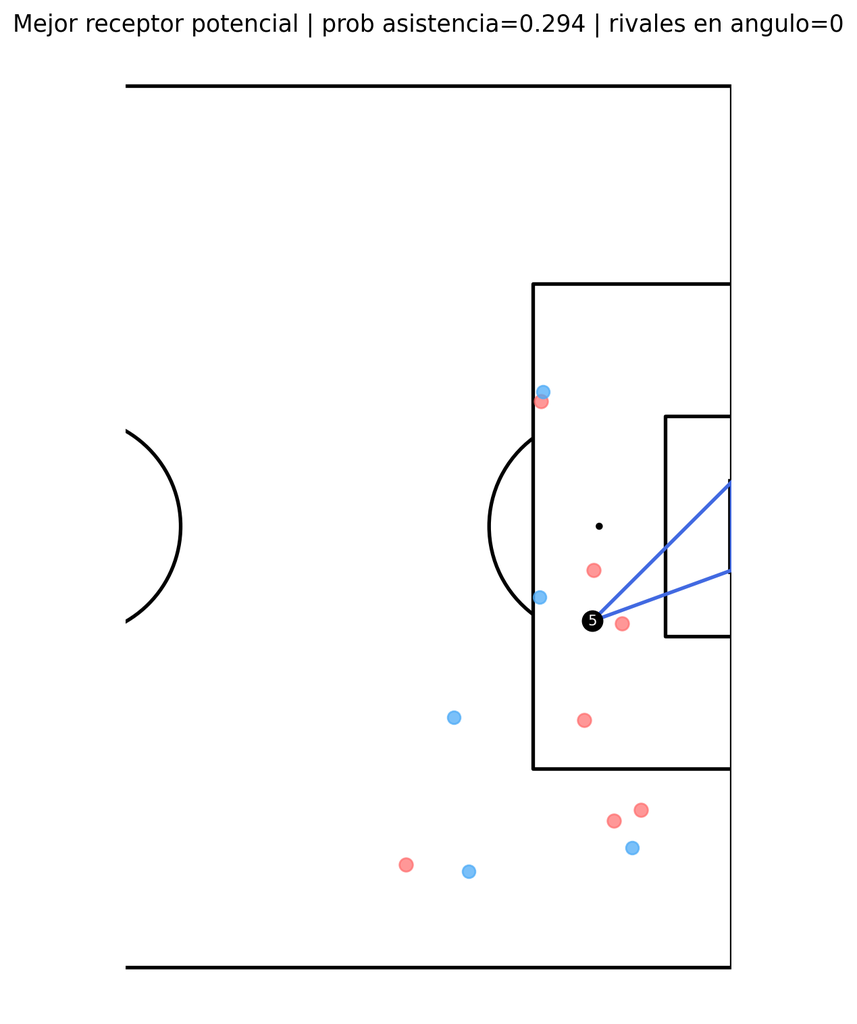

```python
def plot_mejor_receptor_pase(row, tabla_receptores):
  if tabla_receptores.empty:
    print('No hay receptores visibles para visualizar.')
    return

  mejor = tabla_receptores.sort_values('probabilidad_asistencia', ascending=False).iloc[0]
  x_ref = mejor['x_receptor']
  y_ref = mejor['y_receptor']
  rivales_frame = row['posiciones_rivales'] if isinstance(row['posiciones_rivales'], list) else []
  companeros_frame = row['posiciones_compañeros'] if isinstance(row['posiciones_compañeros'], list) else []

  metricas = calcular_metricas_punto(x_ref, y_ref, rivales_frame)
  rivales_tripleta = []
  for rival in rivales_frame:
    x_rival = rival.get('x', np.nan)
    y_rival = rival.get('y', np.nan)
    if pd.isna(x_rival) or pd.isna(y_rival):
      continue
    rivales_tripleta.append((x_rival, y_rival, punto_en_triangulo(x_rival, y_rival, x_ref, y_ref)))

  rivales_block_x = [x for x, y, bloquea in rivales_tripleta if bloquea]
  rivales_block_y = [y for x, y, bloquea in rivales_tripleta if bloquea]
  rivales_xy = extraer_xy_frame(rivales_frame)
  companeros_xy = extraer_xy_frame(companeros_frame)

  pitch = Pitch(pitch_type='statsbomb', line_color='black', pitch_color='white')
  fig, ax = pitch.draw(figsize=(12, 8))
  ax.set_xlim(65, 120)

  ax.plot([x_ref, POSTE_1[0]], [y_ref, POSTE_1[1]], color='royalblue', linewidth=2, zorder=2)
  ax.plot([x_ref, POSTE_2[0]], [y_ref, POSTE_2[1]], color='royalblue', linewidth=2, zorder=2)
  ax.plot([POSTE_1[0], POSTE_2[0]], [POSTE_1[1], POSTE_2[1]], color='royalblue', linewidth=2, zorder=2)

  if len(rivales_xy) > 0:
    pitch.scatter([x for x, _, _ in rivales_xy], [y for _, y, _ in rivales_xy], ax=ax, color='#ff6b6b', s=55, alpha=0.7, zorder=3)
  if len(rivales_block_x) > 0:
    pitch.scatter(rivales_block_x, rivales_block_y, ax=ax, color='#c1121f', edgecolors='black', s=85, zorder=4)
  if len(companeros_xy) > 0:
    pitch.scatter([x for x, _, _ in companeros_xy], [y for _, y, _ in companeros_xy], ax=ax, color='#4dabf7', s=50, alpha=0.75, zorder=3)

  pitch.scatter([x_ref], [y_ref], ax=ax, color='black', s=120, marker='o', zorder=5)
  ax.text(x_ref, y_ref, str(int(mejor['id_receptor_frame'])), color='white', ha='center', va='center', fontsize=8, zorder=6)

  ax.set_title(
    f"Mejor receptor potencial | prob asistencia={mejor['probabilidad_asistencia']:.3f} | "
    f"rivales en angulo={int(metricas['num_rivales_angulo_companero'])}",
    fontsize=13,
  )
  plt.show()


plot_mejor_receptor_pase(pase_ejemplo.iloc[0], tabla_receptores_pase)
```

## 6.8 Paso 6. Grid de opciones de pase y probabilidad de asistencia

**Mostrar código**

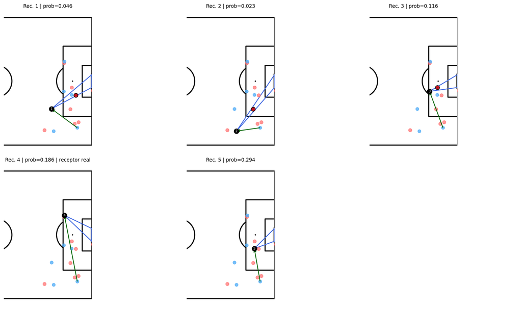

```python
def plot_grid_receptores_pase(row, tabla_receptores, ncols=3):
  if tabla_receptores.empty:
    print('No hay receptores visibles para visualizar.')
    return

  receptores = tabla_receptores.sort_values('id_receptor_frame').to_dict('records')
  rivales_frame = row['posiciones_rivales'] if isinstance(row['posiciones_rivales'], list) else []
  companeros_frame = row['posiciones_compañeros'] if isinstance(row['posiciones_compañeros'], list) else []

  n = len(receptores)
  nrows = int(np.ceil(n / ncols))
  fig, axes = plt.subplots(nrows=nrows, ncols=ncols, figsize=(ncols * 5.0, nrows * 4.0))
  axes = np.array(axes).reshape(-1)
  pitch = Pitch(pitch_type='statsbomb', line_color='black', pitch_color='white')

  rivales_xy = extraer_xy_frame(rivales_frame)
  companeros_xy = extraer_xy_frame(companeros_frame)
  x_pase, y_pase = row.get('x_pase', np.nan), row.get('y_pase', np.nan)

  for ax_idx, ax in enumerate(axes):
    if ax_idx >= n:
      ax.axis('off')
      continue

    receptor = receptores[ax_idx]
    x_ref = receptor['x_receptor']
    y_ref = receptor['y_receptor']
    prob = receptor['probabilidad_asistencia']

    metricas = calcular_metricas_punto(x_ref, y_ref, rivales_frame)
    rivales_tripleta = []
    for rival in rivales_frame:
      x_rival = rival.get('x', np.nan)
      y_rival = rival.get('y', np.nan)
      if pd.isna(x_rival) or pd.isna(y_rival):
        continue
      rivales_tripleta.append((x_rival, y_rival, punto_en_triangulo(x_rival, y_rival, x_ref, y_ref)))

    rivales_block_x = [x for x, y, bloquea in rivales_tripleta if bloquea]
    rivales_block_y = [y for x, y, bloquea in rivales_tripleta if bloquea]

    pitch.draw(ax=ax)
    ax.set_xlim(65, 120)

    ax.plot([x_ref, POSTE_1[0]], [y_ref, POSTE_1[1]], color='royalblue', linewidth=1.5, zorder=2)
    ax.plot([x_ref, POSTE_2[0]], [y_ref, POSTE_2[1]], color='royalblue', linewidth=1.5, zorder=2)
    ax.plot([POSTE_1[0], POSTE_2[0]], [POSTE_1[1], POSTE_2[1]], color='royalblue', linewidth=1.5, zorder=2)

    if len(rivales_xy) > 0:
      pitch.scatter([x for x, _, _ in rivales_xy], [y for _, y, _ in rivales_xy], ax=ax, color='#ff6b6b', s=36, alpha=0.7, zorder=3)
    if len(rivales_block_x) > 0:
      pitch.scatter(rivales_block_x, rivales_block_y, ax=ax, color='#c1121f', edgecolors='black', s=56, zorder=4)
    if len(companeros_xy) > 0:
      pitch.scatter([x for x, _, _ in companeros_xy], [y for _, y, _ in companeros_xy], ax=ax, color='#4dabf7', s=32, alpha=0.75, zorder=3)

    if pd.notna(x_pase) and pd.notna(y_pase):
      pitch.arrows(x_pase, y_pase, x_ref, y_ref, ax=ax, color='darkgreen', width=1.4, headwidth=4, zorder=4)

    pitch.scatter([x_ref], [y_ref], ax=ax, color='black', s=78, marker='o', zorder=5)
    ax.text(x_ref, y_ref, str(int(receptor['id_receptor_frame'])), color='white', fontsize=6, ha='center', va='center', zorder=6)

    etiqueta_real = ' | receptor real' if bool(receptor.get('receptor_real_aproximado', False)) else ''
    ax.set_title(
      f"Rec. {int(receptor['id_receptor_frame'])} | prob={prob:.3f}{etiqueta_real}",
      fontsize=9,
    )

  plt.tight_layout()
  plt.show()


plot_grid_receptores_pase(pase_ejemplo.iloc[0], tabla_receptores_pase, ncols=3)
```

# 7 Ranking final de mejores decisiones

Este apartado aplica el criterio anterior a todos los eventos disponibles. La lectura de los resultados es:

- En tiros, el aumento mide `probabilidad del tirador - mejor probabilidad de gol entre compañeros pasables`.
- En pases, el aumento mide `probabilidad del receptor real - mejor probabilidad de asistencia entre otros receptores pasables`.

## 7.1 Mejores decisiones de tiro frente a opciones de pase válidas

**Mostrar código**

```python
def es_mismo_jugador_frame(jugador, x_ref, y_ref, tolerancia=1.5):
  if bool(jugador.get('actor', False)):
    return True

  x_jugador = jugador.get('x', np.nan)
  y_jugador = jugador.get('y', np.nan)
  if pd.isna(x_jugador) or pd.isna(y_jugador) or pd.isna(x_ref) or pd.isna(y_ref):
    return False

  return ((x_jugador - x_ref)**2 + (y_jugador - y_ref)**2)**0.5 <= tolerancia


def calcular_decision_tiro_con_opciones_validas(row):
  x_tirador = row.get('x', np.nan)
  y_tirador = row.get('y', np.nan)
  lista_companeros = row['posiciones_compañeros'] if isinstance(row['posiciones_compañeros'], list) else []
  lista_rivales = row['posiciones_rivales'] if isinstance(row['posiciones_rivales'], list) else []

  prob_tirador = calcular_probabilidad_gol(
    num_rivales_angulo=row.get('num_rivales_angulo', np.nan),
    distancia_rival_mas_cercano=row.get('distancia_rival_mas_cercano', np.nan),
    distancia_porteria=row.get('distancia_centro_porteria', np.nan),
  )

  opciones_validas = []
  for idx, comp in enumerate(lista_companeros, start=1):
    x_comp = comp.get('x', np.nan)
    y_comp = comp.get('y', np.nan)

    if pd.isna(x_comp) or pd.isna(y_comp) or es_mismo_jugador_frame(comp, x_tirador, y_tirador):
      continue

    rivales_cortando = rivales_en_linea_de_pase(x_tirador, y_tirador, x_comp, y_comp, lista_rivales)
    if len(rivales_cortando) > 0:
      continue

    metricas = calcular_metricas_punto(x_comp, y_comp, lista_rivales)
    opciones_validas.append({
      'id_companero_frame': idx,
      'x': x_comp,
      'y': y_comp,
      'probabilidad_gol_opcion': metricas['prob_gol_companero'],
    })

  mejor_opcion = max([opcion['probabilidad_gol_opcion'] for opcion in opciones_validas], default=np.nan)
  aumento = prob_tirador - mejor_opcion if pd.notna(mejor_opcion) else np.nan

  return {
    'probabilidad_gol_tirador': prob_tirador,
    'mejor_probabilidad_gol_opcion_valida': mejor_opcion,
    'aumento_probabilidad_gol': aumento,
    'num_opciones_validas': len(opciones_validas),
    'decision_tiro_mejor_que_pase_valido': pd.notna(aumento) and aumento > 0,
  }


registros_decision_gol = []

for _, row in shots_360_limpio.iterrows():
  resultado = calcular_decision_tiro_con_opciones_validas(row)
  registros_decision_gol.append({
    'match_id': row.get('match_id', np.nan),
    'id_tiro': row.get('id', np.nan),
    'jugador': row.get('player_name', ''),
    'equipo': row.get('team_name', ''),
    'resultado_tiro': row.get('outcome_name', ''),
    'shot_statsbomb_xg': row.get('shot_statsbomb_xg', np.nan),
    **resultado,
  })

decisiones_gol = pd.DataFrame(registros_decision_gol)
decisiones_gol_evaluables = decisiones_gol.dropna(subset=['aumento_probabilidad_gol']).copy()
decisiones_gol_positivas = decisiones_gol_evaluables[
  decisiones_gol_evaluables['decision_tiro_mejor_que_pase_valido']
].copy()

volumen_jugadores_gol = (
  decisiones_gol_evaluables
  .groupby('jugador', as_index=False)
  .agg(
    tiros_evaluados=('id_tiro', 'count'),
    prob_media_tiro=('probabilidad_gol_tirador', 'mean'),
    mejor_opcion_valida_media=('mejor_probabilidad_gol_opcion_valida', 'mean'),
    opciones_validas_media=('num_opciones_validas', 'mean'),
  )
)

ranking_jugadores_gol = (
  decisiones_gol_positivas
  .groupby('jugador', as_index=False)
  .agg(
    decisiones_tiro_mejores=('id_tiro', 'count'),
    aumento_total_prob_gol=('aumento_probabilidad_gol', 'sum'),
    aumento_medio_prob_gol=('aumento_probabilidad_gol', 'mean'),
  )
)

ranking_jugadores_gol = ranking_jugadores_gol.merge(volumen_jugadores_gol, on='jugador', how='left')
ranking_jugadores_gol['pct_decisiones_tiro_mejores'] = (
  ranking_jugadores_gol['decisiones_tiro_mejores'] / ranking_jugadores_gol['tiros_evaluados']
)

ranking_jugadores_gol = ranking_jugadores_gol.sort_values(
  ['aumento_total_prob_gol', 'aumento_medio_prob_gol'],
  ascending=[False, False],
)

ranking_jugadores_gol.head(15).style.format({
  'tiros_evaluados': '{:.0f}',
  'decisiones_tiro_mejores': '{:.0f}',
  'aumento_total_prob_gol': '{:.3f}',
  'aumento_medio_prob_gol': '{:.3f}',
  'prob_media_tiro': '{:.3f}',
  'mejor_opcion_valida_media': '{:.3f}',
  'opciones_validas_media': '{:.2f}',
  'pct_decisiones_tiro_mejores': '{:.1%}',
}).hide(axis='index')
```

| jugador | decisiones_tiro_mejores | aumento_total_prob_gol | aumento_medio_prob_gol | tiros_evaluados | prob_media_tiro | mejor_opcion_valida_media | opciones_validas_media | pct_decisiones_tiro_mejores |
| --- | --- | --- | --- | --- | --- | --- | --- | --- |
| Jeremie Frimpong | 21 | 2.381 | 0.113 | 34 | 0.133 | 0.093 | 1.79 | 61.8% |
| Victor Okoh Boniface | 24 | 2.358 | 0.098 | 39 | 0.146 | 0.109 | 1.74 | 61.5% |
| Florian Wirtz | 24 | 2.119 | 0.088 | 51 | 0.101 | 0.097 | 2.27 | 47.1% |
| Jonas Hofmann | 24 | 1.488 | 0.062 | 51 | 0.097 | 0.123 | 2.55 | 47.1% |
| Patrik Schick | 14 | 1.430 | 0.102 | 24 | 0.182 | 0.148 | 1.75 | 58.3% |
| Nathan Tella | 13 | 0.999 | 0.077 | 17 | 0.107 | 0.054 | 1.59 | 76.5% |
| Adam Hložek | 5 | 0.792 | 0.158 | 11 | 0.151 | 0.125 | 1.82 | 45.5% |
| Jonathan Tah | 4 | 0.731 | 0.183 | 13 | 0.101 | 0.115 | 2.00 | 30.8% |
| Robert Andrich | 11 | 0.723 | 0.066 | 22 | 0.091 | 0.125 | 2.86 | 50.0% |
| Alejandro Grimaldo García | 10 | 0.585 | 0.059 | 56 | 0.062 | 0.140 | 3.18 | 17.9% |
| Piero Martín Hincapié Reyna | 4 | 0.544 | 0.136 | 8 | 0.171 | 0.127 | 1.88 | 50.0% |
| Amine Adli | 5 | 0.327 | 0.065 | 14 | 0.119 | 0.127 | 2.14 | 35.7% |
| Exequiel Alejandro Palacios | 4 | 0.227 | 0.057 | 20 | 0.071 | 0.122 | 2.70 | 20.0% |
| Edmond Fayçal Tapsoba | 3 | 0.226 | 0.075 | 10 | 0.056 | 0.137 | 2.30 | 30.0% |
| Borja Iglesias Quintas | 2 | 0.148 | 0.074 | 4 | 0.112 | 0.147 | 1.75 | 50.0% |

## 7.2 Mejores decisiones de asistencia frente a receptores válidos

**Mostrar código**

```python
def calcular_decision_pase_con_receptores_validos(row):
  receptores = calcular_probabilidad_asistencia_pase(row)
  if len(receptores) == 0:
    return {
      'probabilidad_asistencia_receptor_real': np.nan,
      'mejor_probabilidad_asistencia_opcion_valida': np.nan,
      'aumento_probabilidad_asistencia': np.nan,
      'num_receptores_validos': 0,
      'receptor_real_pasable': False,
      'decision_pase_mejor_que_receptor_valido': False,
    }

  lista_rivales = row['posiciones_rivales'] if isinstance(row['posiciones_rivales'], list) else []
  x_pase = row.get('x_pase', np.nan)
  y_pase = row.get('y_pase', np.nan)

  for receptor in receptores:
    rivales_cortando = rivales_en_linea_de_pase(
      x_pase,
      y_pase,
      receptor['x_receptor'],
      receptor['y_receptor'],
      lista_rivales,
    )
    receptor['pase_posible_sin_rival'] = len(rivales_cortando) == 0
    receptor['num_rivales_cortando_pase'] = len(rivales_cortando)

  receptor_real = next(
    (receptor for receptor in receptores if receptor.get('receptor_real_aproximado', False)),
    None,
  )

  if receptor_real is None:
    return {
      'probabilidad_asistencia_receptor_real': np.nan,
      'mejor_probabilidad_asistencia_opcion_valida': np.nan,
      'aumento_probabilidad_asistencia': np.nan,
      'num_receptores_validos': sum(1 for receptor in receptores if receptor['pase_posible_sin_rival']),
      'receptor_real_pasable': False,
      'decision_pase_mejor_que_receptor_valido': False,
    }

  opciones_validas_alternativas = [
    receptor
    for receptor in receptores
    if receptor['pase_posible_sin_rival']
    and receptor['id_receptor_frame'] != receptor_real['id_receptor_frame']
  ]

  mejor_opcion = max(
    [receptor['probabilidad_asistencia'] for receptor in opciones_validas_alternativas],
    default=np.nan,
  )
  prob_receptor_real = receptor_real['probabilidad_asistencia']
  aumento = prob_receptor_real - mejor_opcion if pd.notna(mejor_opcion) else np.nan
  receptor_real_pasable = bool(receptor_real.get('pase_posible_sin_rival', False))

  return {
    'probabilidad_asistencia_receptor_real': prob_receptor_real,
    'mejor_probabilidad_asistencia_opcion_valida': mejor_opcion,
    'aumento_probabilidad_asistencia': aumento,
    'num_receptores_validos': sum(1 for receptor in receptores if receptor['pase_posible_sin_rival']),
    'receptor_real_pasable': receptor_real_pasable,
    'decision_pase_mejor_que_receptor_valido': receptor_real_pasable and pd.notna(aumento) and aumento > 0,
  }


registros_decision_asistencia = []

for _, row in pases_tiro_360.iterrows():
  resultado = calcular_decision_pase_con_receptores_validos(row)
  registros_decision_asistencia.append({
    'match_id': row.get('match_id', np.nan),
    'id_pase': row.get('pass_id', np.nan),
    'id_tiro': row.get('shot_id', np.nan),
    'jugador': row.get('pasador', ''),
    'tirador': row.get('tirador', ''),
    'resultado_tiro': row.get('outcome_name', ''),
    'shot_statsbomb_xg': row.get('shot_statsbomb_xg', np.nan),
    **resultado,
  })

decisiones_asistencia = pd.DataFrame(registros_decision_asistencia)
decisiones_asistencia_evaluables = decisiones_asistencia.dropna(subset=['aumento_probabilidad_asistencia']).copy()
decisiones_asistencia_positivas = decisiones_asistencia_evaluables[
  decisiones_asistencia_evaluables['decision_pase_mejor_que_receptor_valido']
].copy()

volumen_jugadores_asistencia = (
  decisiones_asistencia_evaluables
  .groupby('jugador', as_index=False)
  .agg(
    pases_evaluados=('id_pase', 'count'),
    prob_media_receptor_real=('probabilidad_asistencia_receptor_real', 'mean'),
    mejor_opcion_valida_media=('mejor_probabilidad_asistencia_opcion_valida', 'mean'),
    receptores_validos_media=('num_receptores_validos', 'mean'),
  )
)

ranking_jugadores_asistencia = (
  decisiones_asistencia_positivas
  .groupby('jugador', as_index=False)
  .agg(
    decisiones_pase_mejores=('id_pase', 'count'),
    aumento_total_prob_asistencia=('aumento_probabilidad_asistencia', 'sum'),
    aumento_medio_prob_asistencia=('aumento_probabilidad_asistencia', 'mean'),
  )
)

ranking_jugadores_asistencia = ranking_jugadores_asistencia.merge(volumen_jugadores_asistencia, on='jugador', how='left')
ranking_jugadores_asistencia['pct_decisiones_pase_mejores'] = (
  ranking_jugadores_asistencia['decisiones_pase_mejores'] / ranking_jugadores_asistencia['pases_evaluados']
)

ranking_jugadores_asistencia = ranking_jugadores_asistencia.sort_values(
  ['aumento_total_prob_asistencia', 'aumento_medio_prob_asistencia'],
  ascending=[False, False],
)

ranking_jugadores_asistencia.head(15).style.format({
  'pases_evaluados': '{:.0f}',
  'decisiones_pase_mejores': '{:.0f}',
  'aumento_total_prob_asistencia': '{:.3f}',
  'aumento_medio_prob_asistencia': '{:.3f}',
  'prob_media_receptor_real': '{:.3f}',
  'mejor_opcion_valida_media': '{:.3f}',
  'receptores_validos_media': '{:.2f}',
  'pct_decisiones_pase_mejores': '{:.1%}',
}).hide(axis='index')
```

| jugador | decisiones_pase_mejores | aumento_total_prob_asistencia | aumento_medio_prob_asistencia | pases_evaluados | prob_media_receptor_real | mejor_opcion_valida_media | receptores_validos_media | pct_decisiones_pase_mejores |
| --- | --- | --- | --- | --- | --- | --- | --- | --- |
| Jonas Hofmann | 14 | 0.854 | 0.061 | 70 | 0.114 | 0.075 | 2.53 | 20.0% |
| Florian Wirtz | 16 | 0.449 | 0.028 | 57 | 0.118 | 0.082 | 2.47 | 28.1% |
| Alejandro Grimaldo García | 3 | 0.363 | 0.121 | 66 | 0.171 | 0.083 | 2.42 | 4.5% |
| Exequiel Alejandro Palacios | 6 | 0.290 | 0.048 | 29 | 0.055 | 0.055 | 3.03 | 20.7% |
| Jeremie Frimpong | 4 | 0.273 | 0.068 | 24 | 0.165 | 0.063 | 2.00 | 16.7% |
| Amine Adli | 3 | 0.125 | 0.042 | 13 | 0.102 | 0.077 | 3.23 | 23.1% |
| Adam Hložek | 3 | 0.111 | 0.037 | 5 | 0.064 | 0.041 | 1.80 | 60.0% |
| Josip Stanišić | 2 | 0.105 | 0.053 | 8 | 0.131 | 0.076 | 2.50 | 25.0% |
| Victor Okoh Boniface | 4 | 0.098 | 0.025 | 18 | 0.101 | 0.042 | 2.33 | 22.2% |
| Odilon Kossonou | 2 | 0.091 | 0.045 | 9 | 0.098 | 0.041 | 2.44 | 22.2% |
| Robert Andrich | 5 | 0.083 | 0.017 | 21 | 0.064 | 0.085 | 3.90 | 23.8% |
| Granit Xhaka | 4 | 0.082 | 0.020 | 46 | 0.081 | 0.079 | 3.85 | 8.7% |
| Borja Iglesias Quintas | 3 | 0.082 | 0.027 | 5 | 0.081 | 0.052 | 2.60 | 60.0% |
| Patrik Schick | 2 | 0.075 | 0.037 | 8 | 0.182 | 0.113 | 2.25 | 25.0% |
| Edmond Fayçal Tapsoba | 3 | 0.061 | 0.020 | 10 | 0.055 | 0.048 | 3.70 | 30.0% |

## 7.3 Resumen combinado de toma de decisión

**Mostrar código**

```python
ranking_gol_resumen = ranking_jugadores_gol[[
  'jugador',
  'tiros_evaluados',
  'decisiones_tiro_mejores',
  'aumento_total_prob_gol',
  'aumento_medio_prob_gol',
]].copy()

ranking_asistencia_resumen = ranking_jugadores_asistencia[[
  'jugador',
  'pases_evaluados',
  'decisiones_pase_mejores',
  'aumento_total_prob_asistencia',
  'aumento_medio_prob_asistencia',
]].copy()

ranking_combinado_decision = ranking_gol_resumen.merge(
  ranking_asistencia_resumen,
  on='jugador',
  how='outer',
).fillna(0)

ranking_combinado_decision['acciones_evaluadas'] = (
  ranking_combinado_decision['tiros_evaluados'] + ranking_combinado_decision['pases_evaluados']
)
ranking_combinado_decision['decisiones_mejores'] = (
  ranking_combinado_decision['decisiones_tiro_mejores'] + ranking_combinado_decision['decisiones_pase_mejores']
)
ranking_combinado_decision['aumento_total_probabilidad'] = (
  ranking_combinado_decision['aumento_total_prob_gol'] + ranking_combinado_decision['aumento_total_prob_asistencia']
)
ranking_combinado_decision['aumento_medio_probabilidad'] = (
  ranking_combinado_decision['aumento_total_probabilidad']
  /
  ranking_combinado_decision['decisiones_mejores'].replace(0, np.nan)
)

ranking_combinado_decision = ranking_combinado_decision[
  ranking_combinado_decision['decisiones_mejores'] > 0
].sort_values(
  ['aumento_total_probabilidad', 'aumento_medio_probabilidad'],
  ascending=[False, False],
)

ranking_combinado_decision.head(15).style.format({
  'tiros_evaluados': '{:.0f}',
  'pases_evaluados': '{:.0f}',
  'acciones_evaluadas': '{:.0f}',
  'decisiones_tiro_mejores': '{:.0f}',
  'decisiones_pase_mejores': '{:.0f}',
  'decisiones_mejores': '{:.0f}',
  'aumento_total_prob_gol': '{:.3f}',
  'aumento_total_prob_asistencia': '{:.3f}',
  'aumento_total_probabilidad': '{:.3f}',
  'aumento_medio_probabilidad': '{:.3f}',
}).hide(axis='index')
```

| jugador | tiros_evaluados | decisiones_tiro_mejores | aumento_total_prob_gol | aumento_medio_prob_gol | pases_evaluados | decisiones_pase_mejores | aumento_total_prob_asistencia | aumento_medio_prob_asistencia | acciones_evaluadas | decisiones_mejores | aumento_total_probabilidad | aumento_medio_probabilidad |
| --- | --- | --- | --- | --- | --- | --- | --- | --- | --- | --- | --- | --- |
| Jeremie Frimpong | 34 | 21 | 2.381 | 0.113386 | 24 | 4 | 0.273 | 0.068148 | 58 | 25 | 2.654 | 0.106 |
| Florian Wirtz | 51 | 24 | 2.119 | 0.088287 | 57 | 16 | 0.449 | 0.028069 | 108 | 40 | 2.568 | 0.064 |
| Victor Okoh Boniface | 39 | 24 | 2.358 | 0.098253 | 18 | 4 | 0.098 | 0.024571 | 57 | 28 | 2.456 | 0.088 |
| Jonas Hofmann | 51 | 24 | 1.488 | 0.061980 | 70 | 14 | 0.854 | 0.061035 | 121 | 38 | 2.342 | 0.062 |
| Patrik Schick | 24 | 14 | 1.430 | 0.102160 | 8 | 2 | 0.075 | 0.037252 | 32 | 16 | 1.505 | 0.094 |
| Nathan Tella | 17 | 13 | 0.999 | 0.076854 | 0 | 0 | 0.000 | 0.000000 | 17 | 13 | 0.999 | 0.077 |
| Alejandro Grimaldo García | 56 | 10 | 0.585 | 0.058548 | 66 | 3 | 0.363 | 0.121018 | 122 | 13 | 0.949 | 0.073 |
| Adam Hložek | 11 | 5 | 0.792 | 0.158443 | 5 | 3 | 0.111 | 0.036948 | 16 | 8 | 0.903 | 0.113 |
| Robert Andrich | 22 | 11 | 0.723 | 0.065683 | 21 | 5 | 0.083 | 0.016608 | 43 | 16 | 0.806 | 0.050 |
| Jonathan Tah | 13 | 4 | 0.731 | 0.182696 | 8 | 1 | 0.025 | 0.025367 | 21 | 5 | 0.756 | 0.151 |
| Piero Martín Hincapié Reyna | 8 | 4 | 0.544 | 0.135938 | 6 | 3 | 0.035 | 0.011503 | 14 | 7 | 0.578 | 0.083 |
| Exequiel Alejandro Palacios | 20 | 4 | 0.227 | 0.056729 | 29 | 6 | 0.290 | 0.048301 | 49 | 10 | 0.517 | 0.052 |
| Amine Adli | 14 | 5 | 0.327 | 0.065371 | 13 | 3 | 0.125 | 0.041776 | 27 | 8 | 0.452 | 0.057 |
| Edmond Fayçal Tapsoba | 10 | 3 | 0.226 | 0.075245 | 10 | 3 | 0.061 | 0.020399 | 20 | 6 | 0.287 | 0.048 |
| Borja Iglesias Quintas | 4 | 2 | 0.148 | 0.074050 | 5 | 3 | 0.082 | 0.027167 | 9 | 5 | 0.230 | 0.046 |